# Spatial Analysis of Demographic, Housing Prices and Public Transportation Accessibility in Chicago

### Yizhou Wang & Hongtao Huang

#### Master of Regional Planning 25’

# 1 Introduction

Finding an affordable home with easy access to public transportation is a challenge in many cities. Therefore, the relationship between housing prices and public transportation accessibility has become a topic of significant interest, particularly in densely populated urban areas. This research aims to investigate the correlation between median housing values and the availability of public transit routes and stops in Chicago, during the year 2021 and 2018. By examining this relationship, the study seeks to provide valuable insights into the complex interplay between transportation infrastructure, housing affordability, and urban development in a densely populated urban area with intense commute in the Chicago metropolitan area. The findings of this research could inform policymakers, urban planners, and stakeholders in their efforts to promote sustainable and equitable urban growth while ensuring accessibility to essential services.

# 2 Problem Statement

This research question addresses the gap in knowledge regarding how public transit accessibility and ridership variations within Chicago, influence housing prices, and also the demographic and economic properties. Existing research often focuses on broader metropolitan areas or the gentrification effects of new transit lines, however, a more detailed effect of how transit stations influencing housing price in commuter towns are rare. This study will analyze data from 2021, 2018 to determine if housing prices correlate with proximity to different public transportation options (subway stations, bus stops); ridership of the stations nearby, and some demographic and economic indexes across Chicago's diverse communities. Moreover, it is also examining the difference of ridership of Covid and Post-Covid era.

It is hypothesize that in Chicago, house prices are positively correlated by the density of the spatial distribution of public transportation, while at the same time, house prices determine to some extent the housing vacancy in the region as well as the population race, nationality and per capita median income etc.

# 3 Literature Review

## 3.1 Housing Prices and Public Transportation

Recent research has highlighted the intricate relationship between housing prices and public transportation accessibility. Studies by Hess and Almeida (2007) and Lee and Smart (2020) have demonstrated that residential property values tend to increase as the distance to public transit stations decreases, reflecting the importance of transportation convenience for urban residents. Palma (2019) stated that:

"10 minutes less travel time to work imply a 2.8% increase in housing price. The price is very sensitive to socio-economic structure of the commune: a 10% increase in the proportion of one member households causes a 50% increase of the price."

However, this positive correlation has also raised concerns about potential negative impacts, such as the displacement of low-income residents due to rising housing costs. Lee and Smart's (2020) findings suggest that areas with high transportation convenience, particularly those with direct access to major employment centers like New York City, may experience significant increases in poverty rates and the migration of low-income groups to these densely populated areas.

However, there are contraditory finding from the research of Brueckner and Rosenthal (2009). They indicates that communities with concentrated public transportation are more likely to have higher populations of low-income families, as public transit offers a more affordable alternative to car ownership. Conversely, Giulano (2005) found that wealthier residents tend to avoid areas with predominantly bus-based transit systems due to longer travel times.

The Hedonic Price Model is particularly useful in the real estate market, especially in analyzing the relationship between housing prices and public transportation convenience. By decomposing housing prices into contributions of different characteristics, this model can quantitatively evaluate the impact of public transportation proximity on housing value, such as showing that houses near subway stations may be a certain percentage higher than the market average price. This analysis is crucial for urban planners and policymakers as it can guide them to increase housing supply or improve public transportation services in areas with convenient transportation. In addition, the results of the consumer price model can also help real estate developers and investors make wiser investment decisions and predict the potential impact of public transportation development on housing prices (Herath & Maier,2010).

## 3.2 Public Transportation in Chicago

Chicago Department of Transportation The Chicago Department of Transportation is a major participant in the Regional Transportation Authority (RTA). The Regional Transportation Authority oversees the operations of the Chicago Transit Authority (CTA), the Metra rail system, and the Pace bus system. Crum (2020) believes that the establishment of new CTA stations will cause the value of surrounding houses to increase, which promotes gentrification.

Moreover, previous studies have examined Chicago and its surrounding areas, providing a valuable research context for exploring this topic. As a densely populated region with a well-established public transportation network and diverse commuter communities, it offers an opportunity to examine the interplay between housing prices, transit accessibility, and socioeconomic factors.

Some of the major cities have substantially greater percentages of workers reliant on transportation than the national average (5.0%), such as Chicago (28.3%) (U.S. Census Bureau, 2018). With a significant portion of Chicago residents relying on public transportation, the area serves as an ideal case study for understanding the complex dynamics between transportation development, housing affordability, and sustainable urban growth.

## 3.2.1 The Demographic of Public Transportation in Chicago

Chicago also has experienced significant gentrification in its poor neighborhoods, with both housing affordability and transit affordability potentially declining for the minority residents who tend to be low-income (Liu et al., 2021). According to a survey by the Regional Transportation Authority (2021), the majority of current users believe transportation is safe and are either vital workers or minorities. Here are some figures from the survey. It could be informed that each the users of the different transportation means, CTA, Metra, and Pace has slightly different patterns of household income and racial demographics.

[figure not shown]

Income by Service Board and Rider Type

[figure not shown]

Industry Group by Service Board and Rider Type

[figure not shown]

Race/Ethnicity by Rider Type for CTA

[figure not shown]

Race/Ethnicity by Rider Type for Pace

## 3.2.2 Influence of Covid to the Public Transit in Chicago

According to TransitCenter(2021), during the early stages of the pandemic, there was a sharp decline in ridership as lockdowns were implemented and many people avoided public spaces to reduce the risk of transmission. This decline forced transit agencies to reduce services due to decreased demand and financial strain from lost fare revenue. In some areas, service cuts have made it difficult for essential workers—who are disproportionately people of color—to commute, as they are more likely to rely on public transport. In 2021, 10% of Black workers, 5% of Latinx workers, and 5% of Asian workers in the Chicago Metropolitan Statistical Area (compared to 4% of White workers) rode buses to work. Since the COVID-19 pandemic began, people of color are more likely than white people to continue commuting to and from get off work. In 2021, 18% of Black workers, 11% of Latinx workers, 30% of Asian workers and 25% of white workers living in the Chicago area worked remotely.

Therefore, Sukaryavichute and Prytherch (2018) argues that transportation systems are a critical component in achieving economic and social well-being, especially in the context of social justice. Fair transportation discussions should include reflection and improvement on policies to ensure equitable access to transportation services for all, especially disadvantaged groups. This involves critical analysis of existing inequalities and ensuring that transport systems are designed to meet the needs of all, especially those with lower incomes who rely on public transport. In Chicago, studying the connection between housing affordability and public transportation is particularly important because it can reveal and address social inequalities in urban planning. By understanding the interaction between the two, we can more effectively promote equitable urban development strategies, improve the quality of life of low-income residents, and promote the balanced development of society as a whole.

# 4 Methodology plan

### 4.1 Data:

#### 4.1.1 Demographic and Economic data in Block Group: Census API

**Housing Data:**

1. `B25077_001E`: Median value (dollars) of owner-occupied housing units.
2. `B25085_001E`: Price asked for vacant-for-sale-only and sold, not occupied housing units.
3. `B25001_001E`: Total housing units.
4. `B25002_003E`: Vacant housing units.
5. `B25003_002E`: Owner-occupied housing units.
6. `B25003_003E`: Renter-occupied housing units.

**Demographic Data:**

1. `B06011_001E`: Median income in the past 12 months (in 2019 inflation-adjusted dollars) by place of birth in the United States.
2. `B05007_001E`: Foreign-born population.
3. `B02001_001E`: Total population by race
4. `B02001_002E`: Total white population by race

#### 4.1.2 Public Transit Data in Chicago

Stops and Routes in Chicago is available from the datahub of the Chicago Metropolitan Agency for Planning (CMAP)

https://datahub.cmap.illinois.gov/search?categories=%252Fcategories%252Ftransit

Ridership for different Routes is available from the Regional Transportation Authority (RTA) - Mapping and Statistics

https://rtams.org/ridership

**Stops:**

- 2023 CTA Bus Stops - February 7, 2023
- 2023 Pace Bus Stops - May 1, 2023
- 2023 Metra Rail Stations - 2023

**Routes/Lines:**

- 2023 Pace Bus Routes - 2023
- 2023 CTA Bus Routes - February 7, 2023
- 2023 CTA Rail Lines - February 7, 2023
- 2023 Metra Rail Lines - 2023

**Ridership:**

### 4.2 Analysis methods

For this study, Global and Local Moran's I is used to analyze the basic data pattern along with the simple visualizations. Local Global Moran's I is used to evaluate the spatial autocorrelation of housing prices. Global Moran's I is used to measure spatial autocorrelation, determining whether similar values of a variable are clustered together geographically, which helps in identifying patterns such as the clustering or dispersion of demographic groups, real estate values, or accessibility features across a given area.

OLS, spatial regime, spatial lag model, and Spatial Durbin Model are applied to figure out what indicators are related to house prices. For this topic, it is possible to explore the relationship between housing prices and public transportation stops, the corresponding ridership, the distance between each tract and the closest stop, the percentage of non-whites, the median per capita income, and the percentage of immigrants and build a best-fit regression model around housing prices. This analysis will help identify the most significant predictors of housing prices in the city of Chicago and understand the impact of public transportation accessibility on these prices, controlling for other factors.

# 5 Site Analysis of Basic Data

## 5.1 Census Demographic Data

### 5.1 Data Processing

```python
import pandas as pd
import numpy as np
import geopandas as gpd
import matplotlib.pyplot as plt
import seaborn as sns
import pysal as py
from matplotlib import colors
from pysal.viz import splot
from esda.moran import Moran_Local
from splot.esda import plot_moran
sns.set_context(context='paper')
%matplotlib inline
from census import Census
from us import states
from shapely.geometry import Point
from pyproj import Proj, transform
from geopy.distance import great_circle
from pysal.explore import esda
from pysal.lib import weights
from numpy.random import seed
import rioxarray  # Surface data manipulation
import xarray  # Surface data manipulation
from pysal.model import spreg
import statsmodels.formula.api as sm
## warnings is a module that allows you to filter warnings
import warnings
## we are going to ignore all warnings (so they won't print)
warnings.filterwarnings("ignore")
```

```python
c = Census("d9c002dc1334c8f6cbea48d3f10a4176cdf89064")
```

```python
# Retrieving census data for Cook County, Illinois, for the year 2021
_2021_census = c.acs5.state_county_tract(fields=('NAME', 'B25077_001E', 'B25085_001E', 'B25001_001E', 'B25002_003E', 'B25003_002E', 'B25003_003E', 'B06011_001E', 'B05007_001E', 'B02001_001E','B02001_002E'),
                                           state_fips=states.IL.fips,
                                           county_fips="031",  # Cook County, Illinois
                                           tract="*",
                                           year=2021)
# Retrieving census data for Cook County, Illinois, for the year 2021
_2018_census = c.acs5.state_county_tract(fields=('NAME', 'B25077_001E', 'B25085_001E', 'B25001_001E', 'B25002_003E', 'B25003_002E', 'B25003_003E', 'B06011_001E', 'B05007_001E', 'B02001_001E','B02001_002E'),
                                           state_fips=states.IL.fips,
                                           county_fips="031",  # Cook County, Illinois
                                           tract="*",
                                           year=2018)
```

```python
#_2021_census
```

```python
# Convert the data to a pandas dataframe
acs_df_2021 = pd.DataFrame(_2021_census)
# Create a GEOID column by concatenating the state, county, and tract codes
acs_df_2021["GEOID"] = acs_df_2021["state"] + acs_df_2021["county"] + acs_df_2021["tract"]
# Calculate the percentage of non-White population by subtracting the White population from the total population and dividing by the total population
acs_df_2021["nonwhite_perc"] = (acs_df_2021["B02001_001E"] - acs_df_2021["B02001_002E"]) / acs_df_2021["B02001_001E"]
acs_df_2021["foreign_perc"] = acs_df_2021["B05007_001E"] / acs_df_2021["B02001_001E"]
```

```python
acs_df_2021["vacant_unit_perc"] = acs_df_2021["B25002_003E"] / acs_df_2021["B25001_001E"]
acs_df_2021["owner_occupied_perc"] = acs_df_2021["B25003_002E"] / acs_df_2021["B25001_001E"]
acs_df_2021["renter_occupied_perc"] = acs_df_2021["B25003_003E"] / acs_df_2021["B25001_001E"]
```

```python
# Convert the data to a pandas dataframe
acs_df_2018 = pd.DataFrame(_2018_census)
# Create a GEOID column by concatenating the state, county, and tract codes
acs_df_2018["GEOID"] = acs_df_2018["state"] + acs_df_2018["county"] + acs_df_2018["tract"]
# Calculate the percentage of non-White population by subtracting the White population from the total population and dividing by the total population
acs_df_2018["nonwhite_perc"] = (acs_df_2018["B02001_001E"] - acs_df_2018["B02001_002E"]) / acs_df_2018["B02001_001E"]
acs_df_2018["foreign_perc"] = acs_df_2018["B05007_001E"] / acs_df_2018["B02001_001E"]
```

```python
acs_df_2018["vacant_unit_perc"] = acs_df_2018["B25002_003E"] / acs_df_2018["B25001_001E"]
acs_df_2018["owner_occupied_perc"] = acs_df_2018["B25003_002E"] / acs_df_2018["B25001_001E"]
acs_df_2018["renter_occupied_perc"] = acs_df_2018["B25003_003E"] / acs_df_2018["B25001_001E"]
```

```python
# Read the shapefile for Cook County
cook_tract = gpd.read_file("https://www2.census.gov/geo/tiger/TIGER2021/TRACT/tl_2021_17_tract.zip")
# Filter the tracts for Cook County only
cook_tract = cook_tract[cook_tract["COUNTYFP"] == "031"]
```

```python
cook_census_geo_2021 = cook_tract.merge(acs_df_2021, left_on = 'GEOID', right_on = 'GEOID')
cook_census_geo_2021.describe()
```

|  | ALAND | AWATER | B25077_001E | B25085_001E | B25001_001E | B25002_003E | B25003_002E | B25003_003E | B06011_001E | B05007_001E | B02001_001E | B02001_002E | nonwhite_perc | foreign_perc | vacant_unit_perc | owner_occupied_perc | renter_occupied_perc |
| --- | --- | --- | --- | --- | --- | --- | --- | --- | --- | --- | --- | --- | --- | --- | --- | --- | --- |
| count | 1.332000e+03 | 1.332000e+03 | 1.332000e+03 | 1332.000000 | 1332.000000 | 1332.000000 | 1332.000000 | 1332.000000 | 1.332000e+03 | 1332.000000 | 1332.000000 | 1332.000000 | 1328.000000 | 1328.000000 | 1328.000000 | 1328.000000 | 1328.000000 |
| mean | 1.837350e+06 | 1.341090e+06 | -9.719136e+06 | 20.870120 | 1692.144144 | 157.115616 | 882.239489 | 652.789039 | -3.463530e+06 | 827.337087 | 3953.001502 | 2057.081081 | 0.511296 | 0.192016 | 0.097898 | 0.515126 | 0.386976 |
| std | 3.147841e+06 | 4.704685e+07 | 8.114146e+07 | 28.637381 | 835.675693 | 138.700517 | 564.369966 | 533.515014 | 4.822262e+07 | 778.174197 | 1778.569024 | 1577.538675 | 0.294288 | 0.142000 | 0.071966 | 0.233497 | 0.201916 |
| min | 0.000000e+00 | 0.000000e+00 | -6.666667e+08 | 0.000000 | 0.000000 | 0.000000 | 0.000000 | 0.000000 | -6.666667e+08 | 0.000000 | 0.000000 | 0.000000 | 0.034380 | 0.000000 | 0.000000 | 0.000000 | 0.000000 |
| 25% | 4.110900e+05 | 0.000000e+00 | 1.736750e+05 | 0.000000 | 1124.750000 | 70.000000 | 423.500000 | 295.000000 | 2.683000e+04 | 210.000000 | 2560.250000 | 656.000000 | 0.255031 | 0.071450 | 0.048706 | 0.326816 | 0.220682 |
| 50% | 8.969725e+05 | 0.000000e+00 | 2.483000e+05 | 10.000000 | 1614.500000 | 122.000000 | 794.000000 | 526.000000 | 3.472350e+04 | 589.000000 | 3885.000000 | 1895.500000 | 0.453815 | 0.165461 | 0.081027 | 0.500264 | 0.386741 |
| 75% | 2.147472e+06 | 0.000000e+00 | 3.627000e+05 | 33.000000 | 2114.000000 | 203.250000 | 1264.500000 | 833.000000 | 4.929225e+04 | 1256.000000 | 5145.750000 | 3170.250000 | 0.777141 | 0.300599 | 0.125492 | 0.711206 | 0.541907 |
| max | 6.184753e+07 | 1.717072e+09 | 1.474100e+06 | 219.000000 | 7694.000000 | 1345.000000 | 3108.000000 | 4750.000000 | 1.147500e+05 | 4543.000000 | 11295.000000 | 8515.000000 | 1.000000 | 0.669796 | 0.477829 | 1.000000 | 0.985468 |

```python
cook_census_geo_2018 = cook_tract.merge(acs_df_2018, left_on = 'GEOID', right_on = 'GEOID')
cook_census_geo_2018.describe()
```

|  | ALAND | AWATER | B25077_001E | B25085_001E | B25001_001E | B25002_003E | B25003_002E | B25003_003E | B06011_001E | B05007_001E | B02001_001E | B02001_002E | nonwhite_perc | foreign_perc | vacant_unit_perc | owner_occupied_perc | renter_occupied_perc |
| --- | --- | --- | --- | --- | --- | --- | --- | --- | --- | --- | --- | --- | --- | --- | --- | --- | --- |
| count | 1.288000e+03 | 1.288000e+03 | 1.288000e+03 | 1288.000000 | 1288.000000 | 1288.000000 | 1288.000000 | 1288.000000 | 1.288000e+03 | 1288.000000 | 1288.000000 | 1288.000000 | 1284.000000 | 1284.000000 | 1284.000000 | 1284.000000 | 1284.000000 |
| mean | 1.742769e+06 | 1.382477e+06 | -7.502018e+06 | 28.131988 | 1635.746118 | 169.021739 | 829.319099 | 637.405280 | -2.036330e+06 | 821.369565 | 3914.440217 | 2212.215839 | 0.469626 | 0.191050 | 0.109513 | 0.496794 | 0.393693 |
| std | 2.648591e+06 | 4.784372e+07 | 7.158056e+07 | 33.609735 | 771.371540 | 138.654729 | 541.363786 | 478.766688 | 3.711046e+07 | 789.686418 | 1732.385134 | 1663.625347 | 0.314474 | 0.145032 | 0.078187 | 0.230792 | 0.194565 |
| min | 0.000000e+00 | 0.000000e+00 | -6.666667e+08 | 0.000000 | 0.000000 | 0.000000 | 0.000000 | 0.000000 | -6.666667e+08 | 0.000000 | 0.000000 | 0.000000 | 0.009518 | 0.000000 | 0.000000 | 0.000000 | 0.008403 |
| 25% | 4.019952e+05 | 0.000000e+00 | 1.533000e+05 | 0.000000 | 1106.000000 | 76.000000 | 386.000000 | 306.000000 | 2.235900e+04 | 201.000000 | 2546.250000 | 685.750000 | 0.188690 | 0.067770 | 0.055406 | 0.314252 | 0.235574 |
| 50% | 8.629060e+05 | 0.000000e+00 | 2.215500e+05 | 19.000000 | 1576.000000 | 136.000000 | 750.500000 | 525.500000 | 3.000000e+04 | 569.500000 | 3833.000000 | 2140.500000 | 0.398953 | 0.162402 | 0.090442 | 0.474632 | 0.400432 |
| 75% | 2.038647e+06 | 0.000000e+00 | 3.323750e+05 | 43.000000 | 2058.000000 | 217.250000 | 1183.000000 | 829.500000 | 4.129100e+04 | 1266.000000 | 5138.250000 | 3397.500000 | 0.758785 | 0.305400 | 0.140072 | 0.687850 | 0.546442 |
| max | 4.514031e+07 | 1.717072e+09 | 1.528600e+06 | 311.000000 | 6514.000000 | 1140.000000 | 3382.000000 | 3686.000000 | 1.057860e+05 | 4893.000000 | 10317.000000 | 8467.000000 | 1.000000 | 0.691883 | 0.569182 | 0.971333 | 0.942693 |

```python
cook_census_geo_2018.head()
```

|  | STATEFP | COUNTYFP | TRACTCE | GEOID | NAME_x | NAMELSAD | MTFCC | FUNCSTAT | ALAND | AWATER | ... | B02001_001E | B02001_002E | state | county | tract | nonwhite_perc | foreign_perc | vacant_unit_perc | owner_occupied_perc | renter_occupied_perc |
| --- | --- | --- | --- | --- | --- | --- | --- | --- | --- | --- | --- | --- | --- | --- | --- | --- | --- | --- | --- | --- | --- |
| 0 | 17 | 031 | 221000 | 17031221000 | 2210 | Census Tract 2210 | G5020 | S | 220053 | 0 | ... | 2774.0 | 2099.0 | 17 | 031 | 221000 | 0.243331 | 0.169430 | 0.089847 | 0.297394 | 0.612758 |
| 1 | 17 | 031 | 221100 | 17031221100 | 2211 | Census Tract 2211 | G5020 | S | 440042 | 0 | ... | 5207.0 | 3900.0 | 17 | 031 | 221100 | 0.251008 | 0.288650 | 0.072526 | 0.286263 | 0.641210 |
| 2 | 17 | 031 | 242800 | 17031242800 | 2428 | Census Tract 2428 | G5020 | S | 439630 | 0 | ... | 1542.0 | 1461.0 | 17 | 031 | 242800 | 0.052529 | 0.127756 | 0.079812 | 0.593114 | 0.327074 |
| 3 | 17 | 031 | 242900 | 17031242900 | 2429 | Census Tract 2429 | G5020 | S | 323819 | 0 | ... | 1617.0 | 1229.0 | 17 | 031 | 242900 | 0.239951 | 0.136054 | 0.107987 | 0.388076 | 0.503937 |
| 4 | 17 | 031 | 243000 | 17031243000 | 2430 | Census Tract 2430 | G5020 | S | 324547 | 0 | ... | 2274.0 | 1706.0 | 17 | 031 | 243000 | 0.249780 | 0.174582 | 0.040075 | 0.363467 | 0.596459 |

5 rows × 32 columns

```python
file_path = "data/Boundaries - Neighborhoods.geojson"
chicago_boundary = gpd.read_file(file_path)
chicago_boundary = chicago_boundary.to_crs(cook_census_geo_2021.crs)
cook_census_geo_2021_clipped = gpd.clip(cook_census_geo_2021, chicago_boundary)
cook_census_geo_2018_clipped = gpd.clip(cook_census_geo_2018, chicago_boundary)
```

### 5.2 Visualization of Social-Economic Factors and Housing Price in Chicago

### 5.2.1 Social-Economic Pattern in Chicago

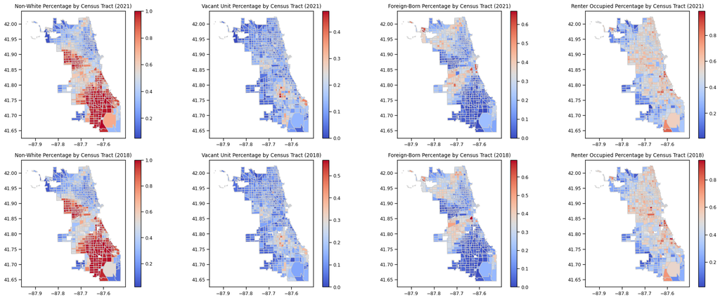

```python
# Create a figure and axis object
fig, axs = plt.subplots(2, 4, figsize=(20, 8))
# Plot 2021 data
columns_2021 = ['nonwhite_perc', 'vacant_unit_perc', 'foreign_perc', 'renter_occupied_perc']
titles_2021 = ['Non-White Percentage by Census Tract (2021)', 'Vacant Unit Percentage by Census Tract (2021)', 'Foreign-Born Percentage by Census Tract (2021)', 'Renter Occupied Percentage by Census Tract (2021)']
for i in range(len(columns_2021)):
    cook_census_geo_2021_clipped.plot(column=columns_2021[i], cmap='coolwarm', linewidth=0.8, ax=axs[0, i], edgecolor='0.8', legend=True)
    axs[0, i].set_title(titles_2021[i])
# Plot 2018 data
columns_2018 = ['nonwhite_perc', 'vacant_unit_perc', 'foreign_perc', 'renter_occupied_perc']
titles_2018 = ['Non-White Percentage by Census Tract (2018)', 'Vacant Unit Percentage by Census Tract (2018)', 'Foreign-Born Percentage by Census Tract (2018)', 'Renter Occupied Percentage by Census Tract (2018)']
for i in range(len(columns_2018)):
    cook_census_geo_2018_clipped.plot(column=columns_2018[i], cmap='coolwarm', linewidth=0.8, ax=axs[1, i], edgecolor='0.8', legend=True)
    axs[1, i].set_title(titles_2018[i])
plt.tight_layout()
plt.show()
```

The proportion of non-white residents and the vacancy rate are both higher in the southern part of Chicago, while the foreign population is concentrated in the north and central areas. Most of the housing in the downtown area is rental, whereas the suburbs are predominantly owner-occupied. From 2018 to 2021, the area southwest of the city center showed significant changes in population and housing market, particularly in the proportion of non-white population and vacant housing. This reflects the dynamic development of these regions in terms of increased racial diversity and changes in housing demand.

### 5.2.1 Housing Price Pattern in Chicago

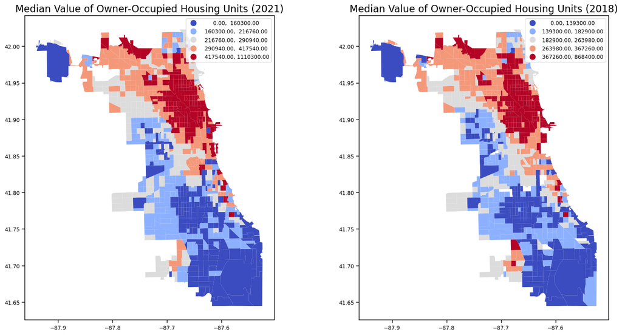

```python
# Create a figure and axis object
fig, ax = plt.subplots(1, 2, figsize=(18, 9))
# Plot the Choropleth map with the filtered data for 2021
cook_census_geo_2021_filtered_clipped.plot(column='B25077_001E', ax=ax[0], legend=True, scheme='Quantiles', cmap='coolwarm')
ax[0].set_title('Median Value of Owner-Occupied Housing Units (2021)', fontsize=16)
# Plot the Choropleth map with the filtered data for 2018
cook_census_geo_2018_filtered_clipped.plot(column='B25077_001E', ax=ax[1], legend=True, scheme='Quantiles', cmap='coolwarm')
ax[1].set_title('Median Value of Owner-Occupied Housing Units (2018)', fontsize=16)
# Show the plot
plt.show()
```

It can be seen that the regions with high housing prices and low housing prices have maintained a relatively stable geographical distribution over the past three years. There has been a price rise in the three years. The housing price ranges in some regions have changed in 2021, but the overall structure remains consistent. High-priced areas are mainly concentrated in the north and along the lake, while the south and southwest remain at lower prices.

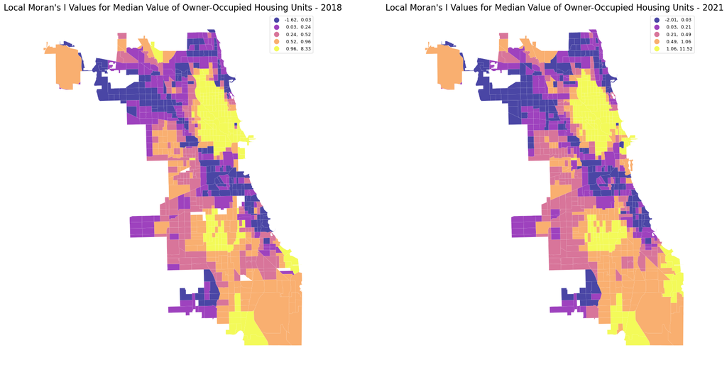

```python
from libpysal.weights import KNN
from esda.moran import Moran_Local

w_2018 = KNN.from_dataframe(cook_census_geo_2018_filtered_clipped, k=8)
w_2018.transform = "R"
lisa_2018 = Moran_Local(cook_census_geo_2018_filtered_clipped["B25077_001E"], w_2018)

w_2021 = KNN.from_dataframe(cook_census_geo_2021_filtered_clipped, k=8)
w_2021.transform = "R"
lisa_2021 = Moran_Local(cook_census_geo_2021_filtered_clipped["B25077_001E"], w_2021)

fig, axs = plt.subplots(nrows=1, ncols=2, figsize=(24, 12))

cook_census_geo_2018_filtered_clipped.assign(Is=lisa_2018.Is).plot(
    column='Is',
    cmap='plasma',
    scheme='quantiles',
    k=5,
    edgecolor='white',
    linewidth=0.1,
    alpha=0.75,
    legend=True,
    ax=axs[0]
)
axs[0].set_title('Local Moran\'s I Values for Median Value of Owner-Occupied Housing Units - 2018', fontsize=16)
axs[0].set_axis_off()

cook_census_geo_2021_filtered_clipped.assign(Is=lisa_2021.Is).plot(
    column='Is',
    cmap='plasma',
    scheme='quantiles',
    k=5,
    edgecolor='white',
    linewidth=0.1,
    alpha=0.75,
    legend=True,
    ax=axs[1]
)
axs[1].set_title('Local Moran\'s I Values for Median Value of Owner-Occupied Housing Units - 2021', fontsize=16)
axs[1].set_axis_off()

# 显示整个图形
plt.show()
```

The local Moran's I statistical values of the median values of homeowners occupying housing units in the Chicago area in 2018 and 2021, were used to evaluate the spatial autocorrelation of housing prices. The dark purple area indicates a significant difference in housing prices compared to the surrounding area, while the yellow area indicates that housing prices are similar or clustered with the surrounding area. From 2018 to 2021, the coverage and intensity of positive Moran's I values (yellow areas) have increased, especially in the south, indicating an increase in spatial clustering of housing prices, with regions with similar housing prices becoming more concentrated. This change may reflect changes in market trends or the centralization of real estate development, providing important spatial insights for policy formulation and market analysis.

## 5.2 Transit Routes and Stations in Chicago

```python
# Load 2023 CTA Bus Routes
cta_bus_routes = gpd.read_file(r"data\2023_CTA_Bus_Routes.geojson")
# Load 2023 CTA Bus Stops
cta_bus_stops = gpd.read_file(r"data\2023_CTA_Bus_Stops.geojson")
# Load 2023 CTA Rail Lines
cta_rail_lines = gpd.read_file(r"data\2023_CTA_Rail_Lines.geojson")
# Load 2023 CTA Rail Stations
cta_rail_stations = gpd.read_file(r"data\2023_CTA_Rail_Stations.geojson")
# Load 2023 Metra Rail Stations
metra_rail_stations = gpd.read_file(r"data\2023_Metra_Rail_Stations.geojson")
# Load 2023 Metra Rail Lines
metra_rail_lines = gpd.read_file(r"data\2023_Metra_Rail_Lines.geojson")
# Load 2023 Pace Bus Stops
pace_bus_stops = gpd.read_file(r"data\2023_Pace_Bus_Stops.geojson")
# Load 2023 Pace Bus Routes
pace_bus_routes = gpd.read_file(r"data\2023_Pace_Bus_Routes.geojson")
# Load Boundaries - Neighborhoods
neighborhood_boundaries = gpd.read_file(r"data\Boundaries - Neighborhoods.geojson")
```

### 5.2.1 CTA Bus Route and Stops

CTA bus routes and stops are located across the whole city and very wide spread. They also have the highest density among all public transits.

```python
cta_bus_routes.head(1)
```

|  | FID | ROUTE | ROUTE0 | NAME | WKDAY | SAT | SUN | SHAPE_LEN | Shape__Length | geometry |
| --- | --- | --- | --- | --- | --- | --- | --- | --- | --- | --- |
| 0 | 1 | 12 | 012 | ROOSEVELT | 1 | 1 | 1 | 62586.111408 | 25595.796952 | MULTILINESTRING ((-87.64792 41.86714, -87.6474... |

```python
cta_bus_stops.head(1)
```

|  | FID | SYSTEMSTOP | STREET | CROSS_ST | DIR | POS | ROUTESSTPG | OWLROUTES | CITY | PUBLIC_NAM | geometry |
| --- | --- | --- | --- | --- | --- | --- | --- | --- | --- | --- | --- |
| 0 | 1 | 3847 | LARAMIE | QUINCY | SB | NS | 57 |  | CHICAGO | Laramie & Quincy | POINT (-87.75503 41.87764) |

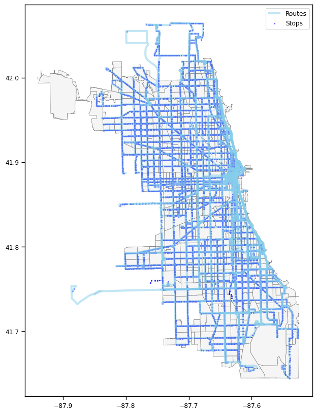

```python
# Create a figure and axis object
fig, ax = plt.subplots(figsize=(10, 10))
# Visualize boundary
cook_census_geo_2021_filtered_clipped.plot(ax=ax, color='#f5f5f5', edgecolor='grey', linewidth=0.5, label='Boundary')
# Visualize routes data (placed behind stops)
cta_bus_routes.plot(ax=ax, color='skyblue', linewidth=3,alpha=0.5,label='Routes')
# Visualize stops data (placed in front of routes)
cta_bus_stops.plot(ax=ax, color='blue', markersize=2, alpha=0.5,label='Stops')
# Add legend
ax.legend()
# Show the plot
plt.show()
```

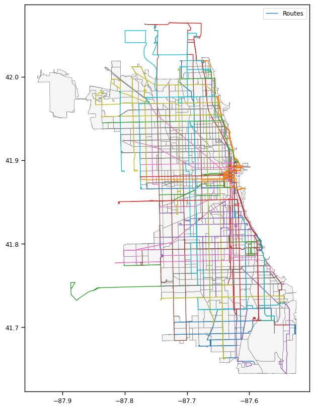

```python
# Create a figure and axis object
fig, ax = plt.subplots(figsize=(10, 10))
# Visualize boundary
cook_census_geo_2021_filtered_clipped.plot(ax=ax, color='#f5f5f5', edgecolor='grey', linewidth=0.5, label='Boundary')
# Visualize routes data (color by 'ROUTE' field)
cta_bus_routes.plot(ax=ax, column='ROUTE', linewidth=1, legend=True, zorder=1, label='Routes')
# Add legend
ax.legend()
# Show the plot
plt.show()
```

### 5.2.2 CTA Rail Lines and Stations

```python
cta_rail_lines.head(1)
```

|  | FID | LINES | DESCRIPTIO | TYPE | LEGEND | SHAPE_LEN | Shape__Length | geometry |
| --- | --- | --- | --- | --- | --- | --- | --- | --- |
| 0 | 1 | Brown, Orange, Pink, Purple (Express) | Tower 12 to Library | 2 | ML | 647.793225 | 264.892948 | LINESTRING (-87.62821 41.87692, -87.62757 41.8... |

```python
cta_rail_stations.head(1)
```

|  | FID | STATION_ID | LONGNAME | LINES | ADDRESS | ADA | PKNRD | POINT_X | POINT_Y | geometry |
| --- | --- | --- | --- | --- | --- | --- | --- | --- | --- | --- |
| 0 | 1 | 230 | Cumberland | Blue Line | 5800 N. Cumberland Avenue | 1 | 1 | 1.118914e+06 | 1.937256e+06 | POINT (-87.83803 41.98430) |

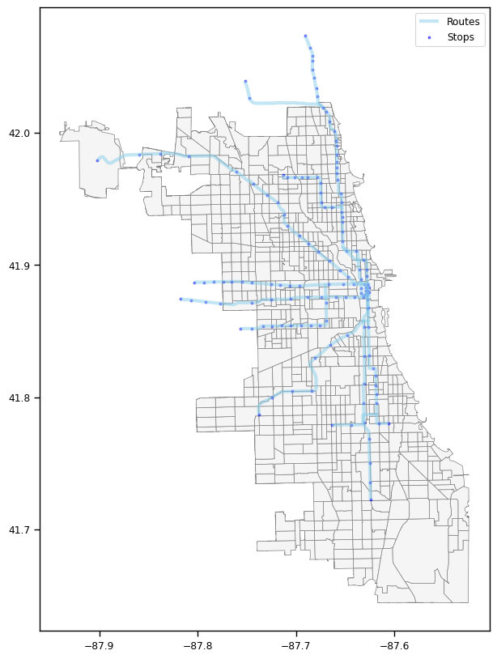

```python
# Create a figure and axis object
fig, ax = plt.subplots(figsize=(10, 10))
# Visualize boundary
cook_census_geo_2021_filtered_clipped.plot(ax=ax, color='#f5f5f5', edgecolor='grey', linewidth=0.5, label='Boundary')
# Visualize routes data (placed behind stops)
cta_rail_lines.plot(ax=ax, color='skyblue', linewidth=3,alpha=0.5,label='Routes')
# Visualize stops data (placed in front of routes)
cta_rail_stations.plot(ax=ax, color='blue', markersize=4, alpha=0.5,label='Stops')
# Add legend
ax.legend()
# Show the plot
plt.show()
```

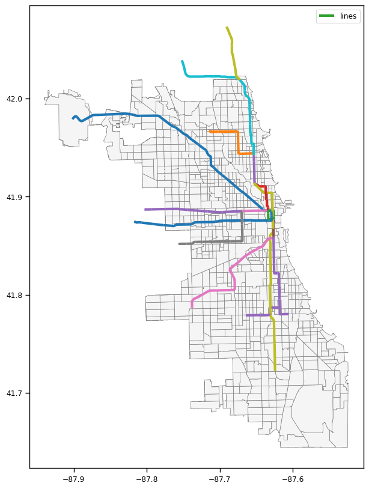

```python
# Create a figure and axis object
fig, ax = plt.subplots(figsize=(10, 10))
# Visualize boundary
cook_census_geo_2021_filtered_clipped.plot(ax=ax, color='#f5f5f5', edgecolor='grey', linewidth=0.5, label='Boundary')
# Visualize routes data (color by 'ROUTE' field)
cta_rail_lines.plot(ax=ax, column='LINES', linewidth=3, legend=True, zorder=1, label='lines')
# Add legend
ax.legend()
# Show the plot
plt.show()
```

### 5.2.3 Pace Bus Route and Stops

Pace bus route and stops are located in the outskirt of the city, linking the suburbs.

```python
pace_bus_routes.head(1)
```

|  | FID | route_shor | Shape_Leng | Shape__Length | geometry |
| --- | --- | --- | --- | --- | --- |
| 0 | 1 | 0 | 0.317273 | 41451.130361 | MULTILINESTRING ((-87.76291 41.97037, -87.7627... |

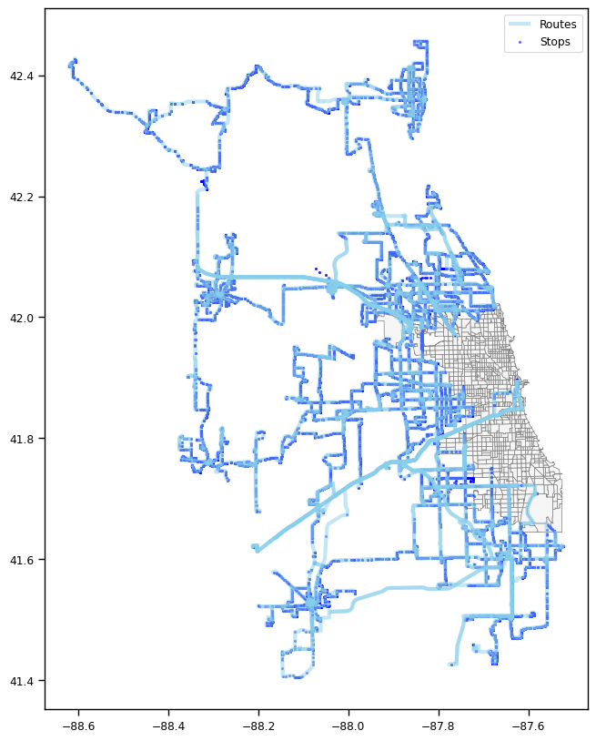

```python
# Create a figure and axis object
fig, ax = plt.subplots(figsize=(10, 10))
# Visualize boundary
cook_census_geo_2021_filtered_clipped.plot(ax=ax, color='#f5f5f5', edgecolor='grey', linewidth=0.5, label='Boundary')
# Visualize routes data (placed behind stops)
pace_bus_routes.plot(ax=ax, color='skyblue', linewidth=3,alpha=0.5,label='Routes')
# Visualize stops data (placed in front of routes)
pace_bus_stops.plot(ax=ax, color='blue', markersize=2, alpha=0.5,label='Stops')
# Add legend
ax.legend()
# Show the plot
plt.show()
```

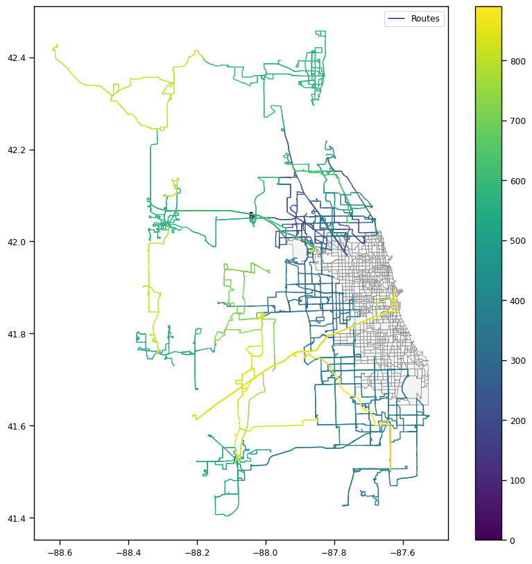

```python
# Create a figure and axis object
fig, ax = plt.subplots(figsize=(10, 10))
# Visualize boundary
cook_census_geo_2021_filtered_clipped.plot(ax=ax, color='#f5f5f5', edgecolor='grey', linewidth=0.5, label='Boundary')
# Visualize routes data (color by 'ROUTE' field)
pace_bus_routes.plot(ax=ax, column='route_shor', linewidth=1, legend=True, zorder=1, label='Routes')
# Add legend
ax.legend()
# Show the plot
plt.show()
```

### 5.2.4 Metra Rail and Lines

Metra rail and lines are passing through the city from all directions linking the suburbs.

```python
metra_rail_lines.head(1)
```

|  | FID | NAME | ASSET_ID | SHAPE_LEN | Shape__Length | geometry |
| --- | --- | --- | --- | --- | --- | --- |
| 0 | 1 | BNSF | 22200006 | 195451.738995 | 79835.207556 | LINESTRING (-87.63884 41.87796, -87.63882 41.8... |

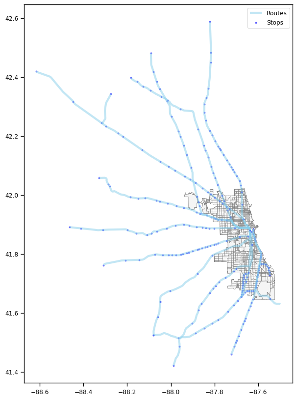

```python
# Create a figure and axis object
fig, ax = plt.subplots(figsize=(10, 10))
# Visualize boundary
cook_census_geo_2021_filtered_clipped.plot(ax=ax, color='#f5f5f5', edgecolor='grey', linewidth=0.5, label='Boundary')
# Visualize routes data (placed behind stops)
metra_rail_lines.plot(ax=ax, color='skyblue', linewidth=3,alpha=0.5,label='Routes')
# Visualize stops data (placed in front of routes)
metra_rail_stations.plot(ax=ax, color='blue', markersize=4, alpha=0.5,label='Stops')
# Add legend
ax.legend()
# Show the plot
plt.show()
```

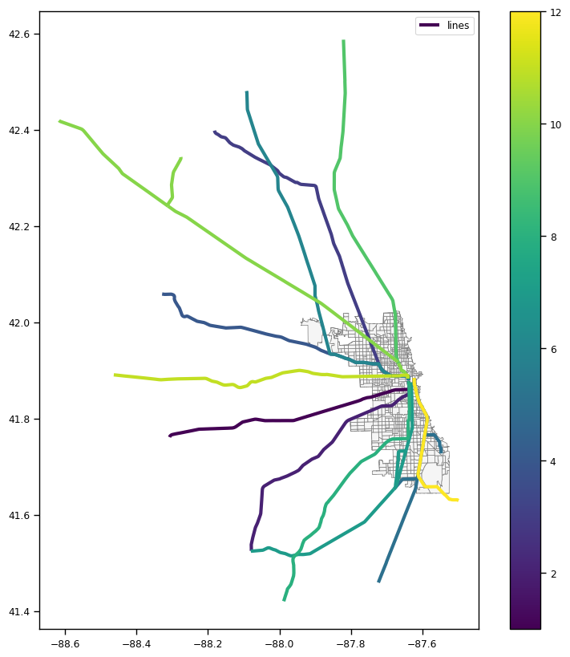

```python
# Create a figure and axis object
fig, ax = plt.subplots(figsize=(10, 10))
# Visualize boundary
cook_census_geo_2021_filtered_clipped.plot(ax=ax, color='#f5f5f5', edgecolor='grey', linewidth=0.5, label='Boundary')
# Visualize routes data (color by 'ROUTE' field)
metra_rail_lines.plot(ax=ax, column='FID', linewidth=3, legend=True, zorder=1, label='lines')
# Add legend
ax.legend()
# Show the plot
plt.show()
```

## 5.3 Data Merging of Ridership Data

Because the CTA and Metra Rail datasets are the only ones that provide station-by-station ridership figures, however, Metra Rail contributes more contribute to suburbs rather than the city of Chicago, therefore, only CTA data is chosen to be analyzed in this project. Additionally, the average weekday, Saturday, and Sunday's ridership across all months of CTA Bus is calculated. It is important to note that the CTA dataset is the only one that includes data from both 2018 and 2021.

### 5.3.1 CTA Ridership Data

```python
file_path = r"data\CTA_Average_Rail_Station_Ridership_1999_2023.csv"
cta_ridership = pd.read_csv(file_path)
cta_ridership_2018 = cta_ridership[(cta_ridership['YEAR'] == 2018) & (cta_ridership['DAY_TYPE'] == 'Weekday')]
cta_ridership_2018 = cta_ridership_2018.groupby('RIDERSHIP_ID').agg({'DAILY_AVG_RIDES': 'mean'})
cta_ridership_2018.reset_index(inplace=True)
cta_ridership_2018.rename(columns={'RIDERSHIP_ID': 'STATION_ID'}, inplace=True)
cta_ridership_2018.head()
```

|  | STATION_ID | DAILY_AVG_RIDES |
| --- | --- | --- |
| 0 | 10 | 1934.250000 |
| 1 | 20 | 3746.916667 |
| 2 | 30 | 1396.000000 |
| 3 | 40 | 7961.416667 |
| 4 | 50 | 3639.750000 |

```python
file_path = r"data\CTA_Average_Rail_Station_Ridership_1999_2023.csv"
cta_ridership = pd.read_csv(file_path)
cta_ridership_2021 = cta_ridership[(cta_ridership['YEAR'] == 2021) & (cta_ridership['DAY_TYPE'] == 'Weekday')]
cta_ridership_2021 = cta_ridership_2021.groupby('RIDERSHIP_ID').agg({'DAILY_AVG_RIDES': 'mean'})
cta_ridership_2021.reset_index(inplace=True)
cta_ridership_2021.rename(columns={'RIDERSHIP_ID': 'STATION_ID'}, inplace=True)
cta_ridership_2021.head()
```

|  | STATION_ID | DAILY_AVG_RIDES |
| --- | --- | --- |
| 0 | 10 | 551.250000 |
| 1 | 20 | 1404.833333 |
| 2 | 30 | 657.916667 |
| 3 | 40 | 1703.333333 |
| 4 | 50 | 1163.083333 |

### 5.3.2 Metra Ridership Data

```python
file_path = r"data\Metra_Ridership_by_Station_Boarding_Alighting Survey_1979_2018_0.csv"
metra_ridership = pd.read_csv(file_path)
metra_ridership_2018 = metra_ridership[(metra_ridership['YEAR'] == 2018)]
metra_ridership_2018 = metra_ridership_2018.groupby('STATION').agg({'BOARDS': 'mean','ALIGHTS': 'mean'})
metra_ridership_2018.head()
```

| STATION | BOARDS | ALIGHTS |
| --- | --- | --- |
| 103rd Street (Beverly Hills) | 734.0 | 731.0 |
| 103rd Street (Rosemoor) | 36.0 | 34.0 |
| 107th Street | 27.0 | 23.0 |
| 107th Street (Beverly Hills) | 395.0 | 368.0 |
| 111th Street | 31.0 | 49.0 |

#### Join ridership data to the subway station data

```python
cta_rail_stations.head(1)
```

|  | FID | STATION_ID | LONGNAME | LINES | ADDRESS | ADA | PKNRD | POINT_X | POINT_Y | geometry |
| --- | --- | --- | --- | --- | --- | --- | --- | --- | --- | --- |
| 0 | 1 | 230 | Cumberland | Blue Line | 5800 N. Cumberland Avenue | 1 | 1 | 1.118914e+06 | 1.937256e+06 | POINT (-87.83803 41.98430) |

```python
cta_rail_stations.rename(columns={'LONGNAME': 'NAME'}, inplace=True)
```

```python
cta_rail_stations.head(1)
```

|  | FID | STATION_ID | NAME | LINES | ADDRESS | ADA | PKNRD | POINT_X | POINT_Y | geometry |
| --- | --- | --- | --- | --- | --- | --- | --- | --- | --- | --- |
| 0 | 1 | 230 | Cumberland | Blue Line | 5800 N. Cumberland Avenue | 1 | 1 | 1.118914e+06 | 1.937256e+06 | POINT (-87.83803 41.98430) |

```python
cta_rail_ridership = pd.merge(cta_rail_stations, cta_ridership_2018[['STATION_ID', 'DAILY_AVG_RIDES']], left_on='STATION_ID', right_on='STATION_ID', how='left')
cta_rail_ridership.rename(columns={'DAILY_AVG_RIDES': 'RIDE2018'}, inplace=True)
cta_rail_ridership = pd.merge(cta_rail_ridership, cta_ridership_2021[['STATION_ID', 'DAILY_AVG_RIDES']], left_on='STATION_ID', right_on='STATION_ID', how='left')
cta_rail_ridership.rename(columns={'DAILY_AVG_RIDES': 'RIDE2021'}, inplace=True)
cta_rail_ridership.head()
```

|  | FID | STATION_ID | NAME | LINES | ADDRESS | ADA | PKNRD | POINT_X | POINT_Y | geometry | RIDE2018 | RIDE2021 |
| --- | --- | --- | --- | --- | --- | --- | --- | --- | --- | --- | --- | --- |
| 0 | 1 | 230 | Cumberland | Blue Line | 5800 N. Cumberland Avenue | 1 | 1 | 1.118914e+06 | 1.937256e+06 | POINT (-87.83803 41.98430) | 4498.583333 | 1177.333333 |
| 1 | 2 | 1350 | Oak Park-Lake | Green Line (Lake) | 100 S. Oak Park Avenue | 0 | 0 | 1.131166e+06 | 1.901870e+06 | POINT (-87.79379 41.88700) | 1578.583333 | 426.166667 |
| 2 | 3 | 1260 | Austin-Lake | Green Line (Lake) | 351 N. Austin Blvd | 0 | 0 | 1.136515e+06 | 1.902016e+06 | POINT (-87.77414 41.88730) | 1822.916667 | 701.583333 |
| 3 | 4 | 170 | Ashland-Lake | Green (Lake), Pink | 1601 W. Lake Street | 1 | 0 | 1.165707e+06 | 1.901502e+06 | POINT (-87.66696 41.88532) | 2431.750000 | 992.583333 |
| 4 | 5 | 1160 | Clinton-Lake | Green (Lake), Pink | 540 W. Lake Street | 1 | 0 | 1.172562e+06 | 1.901699e+06 | POINT (-87.64178 41.88571) | 4406.916667 | 1247.250000 |

```python
cta_rail_ridership['railscale'] = cta_rail_ridership['RIDE2021'] / cta_rail_ridership['RIDE2018']
cta_rail_ridership.head()
```

|  | FID | STATION_ID | NAME | LINES | ADDRESS | ADA | PKNRD | POINT_X | POINT_Y | geometry | RIDE2018 | RIDE2021 | railscale |
| --- | --- | --- | --- | --- | --- | --- | --- | --- | --- | --- | --- | --- | --- |
| 0 | 1 | 230 | Cumberland | Blue Line | 5800 N. Cumberland Avenue | 1 | 1 | 1.118914e+06 | 1.937256e+06 | POINT (-87.83803 41.98430) | 4498.583333 | 1177.333333 | 0.261712 |
| 1 | 2 | 1350 | Oak Park-Lake | Green Line (Lake) | 100 S. Oak Park Avenue | 0 | 0 | 1.131166e+06 | 1.901870e+06 | POINT (-87.79379 41.88700) | 1578.583333 | 426.166667 | 0.269968 |
| 2 | 3 | 1260 | Austin-Lake | Green Line (Lake) | 351 N. Austin Blvd | 0 | 0 | 1.136515e+06 | 1.902016e+06 | POINT (-87.77414 41.88730) | 1822.916667 | 701.583333 | 0.384869 |
| 3 | 4 | 170 | Ashland-Lake | Green (Lake), Pink | 1601 W. Lake Street | 1 | 0 | 1.165707e+06 | 1.901502e+06 | POINT (-87.66696 41.88532) | 2431.750000 | 992.583333 | 0.408177 |
| 4 | 5 | 1160 | Clinton-Lake | Green (Lake), Pink | 540 W. Lake Street | 1 | 0 | 1.172562e+06 | 1.901699e+06 | POINT (-87.64178 41.88571) | 4406.916667 | 1247.250000 | 0.283021 |

#### Join ridership data to the bus line data

```python
cta_bus_routes.head(1)
```

|  | FID | ROUTE | ROUTE0 | NAME | WKDAY | SAT | SUN | SHAPE_LEN | Shape__Length | geometry |
| --- | --- | --- | --- | --- | --- | --- | --- | --- | --- | --- |
| 0 | 1 | 12 | 012 | ROOSEVELT | 1 | 1 | 1 | 62586.111408 | 25595.796952 | MULTILINESTRING ((-87.64792 41.86714, -87.6474... |

```python
#cta_bus_routes['ROUTE'].unique()
```

```python
#cta_bus_routes['ROUTE0'].unique()
```

```python
file_path = r"data\CTA_Average_Bus_Ridership_1999_2023.csv"
bus_ridership = pd.read_csv(file_path)
bus_ridership['ROUTE'].unique()
```

```
array(['0', '1', '100', '1001', '103', '106', '108', '11', '111', '111A',
       '112', '115', '119', '12', '120', '121', '124', '125', '126',
       '128', '134', '135', '136', '143', '146', '147', '148', '15',
       '151', '152', '155', '156', '157', '165', '169', '171', '172',
       '18', '19', '192', '2', '20', '201', '206', '21', '22', '24', '26',
       '28', '29', '3', '30', '31', '34', '35', '36', '37', '39', '4',
       '43', '44', '47', '48', '49', '49B', '5', '50', '51', '52', '52A',
       '53', '53A', '54', '54A', '54B', '55', '55A', '55N', '56', '57',
       '59', '6', '60', '62', '62H', '63', '63W', '65', '66', '67', '68',
       '7', '70', '71', '72', '73', '74', '75', '76', '77', '78', '79',
       '8', '80', '81', '81W', '82', '84', '85', '85A', '86', '87', '88',
       '8A', '9', '90', '91', '92', '93', '94', '95', '96', '97', 'J14',
       'X4', 'X49', 'X9', '10', '130', 'X98', '642', '132', '205', '95E',
       '95W', '170', '154', '33', 'R22', 'R39', 'R55', 'R63', 'R69',
       'R79', 'R87', 'R95', '122', '123', '129', '144', '145', '17',
       '49A', '56A', '64', '69', '90N', 'N201', 'X28', '14', '168',
       '53AL', 'X20', 'X3', 'X54', 'X55', 'X80', '174', '200', '38',
       '173', '127', '1002', '25', '40', 'X99', 'X21', '27', '202', '203',
       '204', 'N5', '1003'], dtype=object)
```

```python
bus_ridership.head()
```

|  | ROUTE | YEAR | MONTH | DAY_TYPE | AVG_RIDES |
| --- | --- | --- | --- | --- | --- |
| 0 | 0 | 2023 | 10 | Weekday | 2626 |
| 1 | 0 | 2023 | 10 | Saturday | 4694 |
| 2 | 0 | 2023 | 10 | Sunday - Holiday | 2634 |
| 3 | 1 | 2023 | 10 | Weekday | 1126 |
| 4 | 100 | 2023 | 10 | Weekday | 470 |

#### Calculate CTA bus ridership by weekday, saturday, and sunday

```python
# Filter the data for the years 2018 and 2021
ridership_2018 = bus_ridership[bus_ridership['YEAR'] == 2018]
ridership_2021 = bus_ridership[bus_ridership['YEAR'] == 2021]

# Calculate the average monthly ridership by day type for each route
avg_ridership_2018 = ridership_2018.groupby(['ROUTE', 'DAY_TYPE'])['AVG_RIDES'].mean().unstack()
avg_ridership_2021 = ridership_2021.groupby(['ROUTE', 'DAY_TYPE'])['AVG_RIDES'].mean().unstack()

# Rename the columns as per your requirement
avg_ridership_2018.columns = ['saturday2018', 'sunday2018', 'weekday2018']
avg_ridership_2021.columns = ['saturday2021', 'sunday2021', 'weekday2021']
```

```python
avg_ridership_2018.head()
```

| ROUTE | saturday2018 | sunday2018 | weekday2018 |
| --- | --- | --- | --- |
| 0 | 2710.833333 | 1586.50 | 3680.833333 |
| 1 | NaN | NaN | 1709.833333 |
| 10 | 455.600000 | 473.60 | 521.000000 |
| 100 | NaN | NaN | 569.666667 |
| 1001 | 139.083333 | 121.75 | 85.916667 |

```python
avg_ridership_2021.head()
```

| ROUTE | saturday2021 | sunday2021 | weekday2021 |
| --- | --- | --- | --- |
| 0 | 2079.666667 | 1540.250000 | 3063.500000 |
| 1 | NaN | NaN | 376.833333 |
| 10 | 408.000000 | 331.400000 | 362.250000 |
| 100 | NaN | NaN | 243.416667 |
| 1001 | 463.750000 | 495.583333 | 53.416667 |

#### Merge 2 years ridership data together

```python
cta_bus_routes = pd.merge(cta_bus_routes, avg_ridership_2018, left_on='ROUTE', right_index=True, how='left')
cta_bus_routes = pd.merge(cta_bus_routes, avg_ridership_2021, left_on='ROUTE', right_index=True, how='left')
```

```python
cta_bus_routes.head()
```

|  | FID | ROUTE | ROUTE0 | NAME | WKDAY | SAT | SUN | SHAPE_LEN | Shape__Length | geometry | saturday2018 | sunday2018 | weekday2018 | saturday2021 | sunday2021 | weekday2021 |
| --- | --- | --- | --- | --- | --- | --- | --- | --- | --- | --- | --- | --- | --- | --- | --- | --- |
| 0 | 1 | 12 | 012 | ROOSEVELT | 1 | 1 | 1 | 62586.111408 | 25595.796952 | MULTILINESTRING ((-87.64792 41.86714, -87.6474... | 7589.083333 | 5757.416667 | 12381.416667 | 3761.750000 | 2735.916667 | 5725.083333 |
| 1 | 2 | 121 | 121 | UNION/STREETERVILLE EXPRESS | 1 | 0 | 0 | 24090.823988 | 9866.558032 | MULTILINESTRING ((-87.62451 41.88834, -87.6249... | NaN | NaN | 1111.666667 | NaN | NaN | 130.250000 |
| 2 | 3 | 1 | 001 | BRONZEVILLE/UNION STATION | 1 | 0 | 0 | 34690.953676 | 14214.349988 | MULTILINESTRING ((-87.62327 41.83104, -87.6232... | NaN | NaN | 1709.833333 | NaN | NaN | 376.833333 |
| 3 | 4 | 108 | 108 | HALSTED/95TH | 1 | 0 | 0 | 71888.990825 | 29369.622395 | MULTILINESTRING ((-87.59054 41.65578, -87.5906... | NaN | NaN | 1138.500000 | NaN | NaN | 380.583333 |
| 4 | 5 | 11 | 011 | LINCOLN | 1 | 1 | 1 | 24694.573889 | 10138.959924 | MULTILINESTRING ((-87.68884 41.96677, -87.6888... | 799.583333 | 528.000000 | 1452.333333 | 491.416667 | 337.166667 | 767.000000 |

#### Calculate the weekend bus ridership

```python
# Replace NaN values with 0
cta_bus_routes[['saturday2018', 'sunday2018', 'weekday2018', 'saturday2021', 'sunday2021', 'weekday2021']] = cta_bus_routes[['saturday2018', 'sunday2018', 'weekday2018', 'saturday2021', 'sunday2021', 'weekday2021']].fillna(0)
cta_bus_routes['weekend2018'] = cta_bus_routes['saturday2018'] + cta_bus_routes['sunday2018']
cta_bus_routes['weekend2021'] = cta_bus_routes['saturday2021'] + cta_bus_routes['sunday2021']
# Calculate total ridership for each year
cta_bus_routes['total2018'] = cta_bus_routes['saturday2018'] + cta_bus_routes['sunday2018'] + cta_bus_routes['weekday2018']
cta_bus_routes['total2021'] = cta_bus_routes['saturday2021'] + cta_bus_routes['sunday2021'] + cta_bus_routes['weekday2021']

# Calculate the scale
cta_bus_routes['busscale'] = cta_bus_routes['total2021'] / cta_bus_routes['total2018']
cta_bus_routes.head()
```

|  | FID | ROUTE | ROUTE0 | NAME | WKDAY | SAT | SUN | SHAPE_LEN | Shape__Length | geometry | ... | sunday2018 | weekday2018 | saturday2021 | sunday2021 | weekday2021 | weekend2018 | weekend2021 | total2018 | total2021 | busscale |
| --- | --- | --- | --- | --- | --- | --- | --- | --- | --- | --- | --- | --- | --- | --- | --- | --- | --- | --- | --- | --- | --- |
| 0 | 1 | 12 | 012 | ROOSEVELT | 1 | 1 | 1 | 62586.111408 | 25595.796952 | MULTILINESTRING ((-87.64792 41.86714, -87.6474... | ... | 5757.416667 | 12381.416667 | 3761.750000 | 2735.916667 | 5725.083333 | 13346.500000 | 6497.666667 | 25727.916667 | 12222.750000 | 0.475077 |
| 1 | 2 | 121 | 121 | UNION/STREETERVILLE EXPRESS | 1 | 0 | 0 | 24090.823988 | 9866.558032 | MULTILINESTRING ((-87.62451 41.88834, -87.6249... | ... | 0.000000 | 1111.666667 | 0.000000 | 0.000000 | 130.250000 | 0.000000 | 0.000000 | 1111.666667 | 130.250000 | 0.117166 |
| 2 | 3 | 1 | 001 | BRONZEVILLE/UNION STATION | 1 | 0 | 0 | 34690.953676 | 14214.349988 | MULTILINESTRING ((-87.62327 41.83104, -87.6232... | ... | 0.000000 | 1709.833333 | 0.000000 | 0.000000 | 376.833333 | 0.000000 | 0.000000 | 1709.833333 | 376.833333 | 0.220392 |
| 3 | 4 | 108 | 108 | HALSTED/95TH | 1 | 0 | 0 | 71888.990825 | 29369.622395 | MULTILINESTRING ((-87.59054 41.65578, -87.5906... | ... | 0.000000 | 1138.500000 | 0.000000 | 0.000000 | 380.583333 | 0.000000 | 0.000000 | 1138.500000 | 380.583333 | 0.334285 |
| 4 | 5 | 11 | 011 | LINCOLN | 1 | 1 | 1 | 24694.573889 | 10138.959924 | MULTILINESTRING ((-87.68884 41.96677, -87.6888... | ... | 528.000000 | 1452.333333 | 491.416667 | 337.166667 | 767.000000 | 1327.583333 | 828.583333 | 2779.916667 | 1595.583333 | 0.573968 |

5 rows × 21 columns

# 6 Models

## 6.1 Variables

**General Variables**

`B02001_001E`: Total population by race (abandoned)

`nonwhite_perc`

`foreign_perc`

`vacant_unit_perc`

`owner_occupied_perc` (abandoned)

`renter_occupied_perc` (abandoned)

`B25077_001E`: Median value (dollars) of owner-occupied housing units.

`B25085_001E`: Price asked for vacant-for-sale-only and sold, not occupied housing units. (abandoned)

`RIDE2018`: 2018 average daily Subway ridership by station

`RIDE2021`: 2021 average daily Subway ridership by station

`railscale/busscale` : Total ridership in 2021 devided by 2018's ridership (abandoned)

`saturday2018` : 2018 average monthly saturday bus ridership by line (abandoned)

`sunday2018` : 2018 average monthly sunday/holiday bus ridership by line (abandoned)

`weekend2018` : 2018 average monthly weekend bus ridership by line (abandoned)

`weekday2018` : 2018 average monthly weekday bus ridership by line (abandoned)

`saturday2021`: 2021 average monthly saturday bus ridership by line (abandoned)

`sunday2021` : 2021 average monthly sunday/holiday bus ridership by line (abandoned)

`weekday2021` : 2021 average monthly weekday bus ridership by line (abandoned)

`weekend2021` : 2021 average monthly weekend bus ridership by line (abandoned)

`total2018` : 2018 average monthly bus ridership by line (abandoned)

`total2021` : 2021 average monthly bus ridership by line (abandoned)

**New Variables**

`logPop` : Log `B02001_001E` (abandoned)

`logMidHomeValue` : log `B25077_001E`

`logSaleHouseValue` : log `B25085_001E` (abandoned)

**Distance Variables**

Distance from Tracts' to Cloest CTA bus stop

Distance from Tracts' to Cloest CTA rail stop

Distance from Tracts' to UChicago [-87.60093, 41.78958] pri (abandoned)

Distance from Tracts' to UIC [-87.65100, 41.87366] pub (abandoned)

Distance from Tracts' to Northwestern [-87.67708, 42.05437] pri (abandoned)

Distance from Tracts' to NEIU [-87.72031, 41.97870] pub (abandoned)

Distance from Tracts' to Illinois Tech [-87.62721, 41.83139] pri (abandoned)

Distance from Tracts' to DePaul (Loop) [-87.62723, 41.87775] pub (abandoned)

Distance from Tracts' to DePaul (Lincoln Park) [-87.65878, 41.92500] pub (abandoned)

Distance from Tracts' to Loyola (Lake Shore Campus) [-87.65779, 41.99858] pri (abandoned)

Distance from Tracts' to Loyola (Health Sciences Campus) [-87.83338, 41.86515] pri (abandoned)

Distance from Tracts' to Loyola (Water Tower Campus) [-87.62517, 41.89733] pri (abandoned)

Distance from Tracts' to Chicago State [-87.61350, 41.73000] pub (abandoned)

Distance from Tracts' to CBD (abandoned)

**Relative variables**

Dummy (is_private) : if the closest university to this tract is a private university [1,0] (abandoned)

Dummy Weekday-only bus line, use SAT [1,0] (abandoned)

Dummy Subway with ADA (elevator) [0,1] (abandoned)

Dummy Subway with PKNRD (Parking Pool) [0,1] (abandoned)

Dummy (is_CBD) : if the tract is CBD [1,0]

## 6.2 Data Processing

Calculate log variables

```python
# Replace 0 with 1 in the specified columns of acs_df_2018 and acs_df_2021
acs_df_2018['B02001_001E'] = acs_df_2018['B02001_001E'].replace(0, 1)
acs_df_2021['B02001_001E'] = acs_df_2021['B02001_001E'].replace(0, 1)
acs_df_2018['B25077_001E'] = acs_df_2018['B25077_001E'].replace(0, 1)
acs_df_2021['B25077_001E'] = acs_df_2021['B25077_001E'].replace(0, 1)
acs_df_2018['B25085_001E'] = acs_df_2018['B25085_001E'].replace(0, 1)
acs_df_2021['B25085_001E'] = acs_df_2021['B25085_001E'].replace(0, 1)

# Calculate the logarithm of total population
acs_df_2018['logPop'] = np.log(np.nan_to_num(acs_df_2018['B02001_001E']))
acs_df_2021['logPop'] = np.log(np.nan_to_num(acs_df_2021['B02001_001E']))

# Calculate log of housing values
acs_df_2018['logMidHomeValue'] = np.log(np.nan_to_num(acs_df_2018['B25077_001E']))
acs_df_2021['logMidHomeValue'] = np.log(np.nan_to_num(acs_df_2021['B25077_001E']))
acs_df_2018['logSaleHouseValue'] = np.log(np.nan_to_num(acs_df_2018['B25085_001E']))
acs_df_2021['logSaleHouseValue'] = np.log(np.nan_to_num(acs_df_2021['B25085_001E']))
```

Verify

```python
acs_df_2018.head(1)
```

|  | NAME | B25077_001E | B25085_001E | B25001_001E | B25002_003E | B25003_002E | B25003_003E | B06011_001E | B05007_001E | B02001_001E | ... | tract | GEOID | nonwhite_perc | foreign_perc | vacant_unit_perc | owner_occupied_perc | renter_occupied_perc | logPop | logMidHomeValue | logSaleHouseValue |
| --- | --- | --- | --- | --- | --- | --- | --- | --- | --- | --- | --- | --- | --- | --- | --- | --- | --- | --- | --- | --- | --- |
| 0 | Census Tract 4302, Cook County, Illinois | 439600.0 | 1.0 | 2556.0 | 177.0 | 341.0 | 2038.0 | 18893.0 | 281.0 | 4961.0 | ... | 430200 | 17031430200 | 0.91534 | 0.056642 | 0.069249 | 0.133412 | 0.79734 | 8.509363 | 12.993621 | 0.0 |

1 rows × 23 columns

```python
acs_df_2021.head(1)
```

|  | NAME | B25077_001E | B25085_001E | B25001_001E | B25002_003E | B25003_002E | B25003_003E | B06011_001E | B05007_001E | B02001_001E | ... | tract | GEOID | nonwhite_perc | foreign_perc | vacant_unit_perc | owner_occupied_perc | renter_occupied_perc | logPop | logMidHomeValue | logSaleHouseValue |
| --- | --- | --- | --- | --- | --- | --- | --- | --- | --- | --- | --- | --- | --- | --- | --- | --- | --- | --- | --- | --- | --- |
| 0 | Census Tract 101, Cook County, Illinois | 255000.0 | 63.0 | 2935.0 | 524.0 | 808.0 | 1603.0 | 33768.0 | 951.0 | 4534.0 | ... | 010100 | 17031010100 | 0.557786 | 0.209749 | 0.178535 | 0.275298 | 0.546167 | 8.41936 | 12.449019 | 4.143135 |

1 rows × 23 columns

```python
print(acs_df_2018.columns)
```

```
Index(['NAME', 'B25077_001E', 'B25085_001E', 'B25001_001E', 'B25002_003E',
       'B25003_002E', 'B25003_003E', 'B06011_001E', 'B05007_001E',
       'B02001_001E', 'B02001_002E', 'state', 'county', 'tract', 'GEOID',
       'nonwhite_perc', 'foreign_perc', 'vacant_unit_perc',
       'owner_occupied_perc', 'renter_occupied_perc', 'logPop',
       'logMidHomeValue', 'logSaleHouseValue'],
      dtype='object')
```

Merge the demographic data to geodatabase

```python
acs_df_2018 = cook_tract.merge(acs_df_2018, left_on = 'GEOID', right_on = 'GEOID')
acs_df_2018.head()
```

|  | STATEFP | COUNTYFP | TRACTCE | GEOID | NAME_x | NAMELSAD | MTFCC | FUNCSTAT | ALAND | AWATER | ... | county | tract | nonwhite_perc | foreign_perc | vacant_unit_perc | owner_occupied_perc | renter_occupied_perc | logPop | logMidHomeValue | logSaleHouseValue |
| --- | --- | --- | --- | --- | --- | --- | --- | --- | --- | --- | --- | --- | --- | --- | --- | --- | --- | --- | --- | --- | --- |
| 0 | 17 | 031 | 221000 | 17031221000 | 2210 | Census Tract 2210 | G5020 | S | 220053 | 0 | ... | 031 | 221000 | 0.243331 | 0.169430 | 0.089847 | 0.297394 | 0.612758 | 7.928046 | 12.570716 | 2.302585 |
| 1 | 17 | 031 | 221100 | 17031221100 | 2211 | Census Tract 2211 | G5020 | S | 440042 | 0 | ... | 031 | 221100 | 0.251008 | 0.288650 | 0.072526 | 0.286263 | 0.641210 | 8.557759 | 12.746069 | 3.044522 |
| 2 | 17 | 031 | 242800 | 17031242800 | 2428 | Census Tract 2428 | G5020 | S | 439630 | 0 | ... | 031 | 242800 | 0.052529 | 0.127756 | 0.079812 | 0.593114 | 0.327074 | 7.340836 | 13.010090 | 0.000000 |
| 3 | 17 | 031 | 242900 | 17031242900 | 2429 | Census Tract 2429 | G5020 | S | 323819 | 0 | ... | 031 | 242900 | 0.239951 | 0.136054 | 0.107987 | 0.388076 | 0.503937 | 7.388328 | 12.937479 | 0.000000 |
| 4 | 17 | 031 | 243000 | 17031243000 | 2430 | Census Tract 2430 | G5020 | S | 324547 | 0 | ... | 031 | 243000 | 0.249780 | 0.174582 | 0.040075 | 0.363467 | 0.596459 | 7.729296 | 12.892195 | 2.397895 |

5 rows × 35 columns

```python
print(acs_df_2018.columns)
```

```
Index(['STATEFP', 'COUNTYFP', 'TRACTCE', 'GEOID', 'NAME_x', 'NAMELSAD',
       'MTFCC', 'FUNCSTAT', 'ALAND', 'AWATER', 'INTPTLAT', 'INTPTLON',
       'geometry', 'NAME_y', 'B25077_001E', 'B25085_001E', 'B25001_001E',
       'B25002_003E', 'B25003_002E', 'B25003_003E', 'B06011_001E',
       'B05007_001E', 'B02001_001E', 'B02001_002E', 'state', 'county', 'tract',
       'nonwhite_perc', 'foreign_perc', 'vacant_unit_perc',
       'owner_occupied_perc', 'renter_occupied_perc', 'logPop',
       'logMidHomeValue', 'logSaleHouseValue'],
      dtype='object')
```

```python
acs_df_2021 = cook_tract.merge(acs_df_2021, left_on = 'GEOID', right_on = 'GEOID')
acs_df_2021.head()
```

|  | STATEFP | COUNTYFP | TRACTCE | GEOID | NAME_x | NAMELSAD | MTFCC | FUNCSTAT | ALAND | AWATER | ... | county | tract | nonwhite_perc | foreign_perc | vacant_unit_perc | owner_occupied_perc | renter_occupied_perc | logPop | logMidHomeValue | logSaleHouseValue |
| --- | --- | --- | --- | --- | --- | --- | --- | --- | --- | --- | --- | --- | --- | --- | --- | --- | --- | --- | --- | --- | --- |
| 0 | 17 | 031 | 221000 | 17031221000 | 2210 | Census Tract 2210 | G5020 | S | 220053 | 0 | ... | 031 | 221000 | 0.338911 | 0.205447 | 0.085985 | 0.294927 | 0.619089 | 7.851661 | 12.760819 | 0.000000 |
| 1 | 17 | 031 | 221100 | 17031221100 | 2211 | Census Tract 2211 | G5020 | S | 440042 | 0 | ... | 031 | 221100 | 0.351490 | 0.190084 | 0.109783 | 0.276671 | 0.613546 | 8.411388 | 12.803259 | 2.995732 |
| 2 | 17 | 031 | 242800 | 17031242800 | 2428 | Census Tract 2428 | G5020 | S | 439630 | 0 | ... | 031 | 242800 | 0.118514 | 0.132607 | 0.065156 | 0.543909 | 0.390935 | 7.353082 | 13.169438 | 0.000000 |
| 3 | 17 | 031 | 242900 | 17031242900 | 2429 | Census Tract 2429 | G5020 | S | 323819 | 0 | ... | 031 | 242900 | 0.334938 | 0.249866 | 0.135776 | 0.463362 | 0.400862 | 7.533159 | 12.938441 | 0.000000 |
| 4 | 17 | 031 | 243000 | 17031243000 | 2430 | Census Tract 2430 | G5020 | S | 324547 | 0 | ... | 031 | 243000 | 0.372104 | 0.118582 | 0.068221 | 0.488774 | 0.443005 | 7.696667 | 13.008747 | 0.000000 |

5 rows × 35 columns

Calculate the distance for each tract to the universities

```python
acs_df_2018.crs
```

```
<Geographic 2D CRS: EPSG:4269>
Name: NAD83
Axis Info [ellipsoidal]:
- Lat[north]: Geodetic latitude (degree)
- Lon[east]: Geodetic longitude (degree)
Area of Use:
- name: North America - onshore and offshore: Canada - Alberta; British Columbia; Manitoba; New Brunswick; Newfoundland and Labrador; Northwest Territories; Nova Scotia; Nunavut; Ontario; Prince Edward Island; Quebec; Saskatchewan; Yukon. Puerto Rico. United States (USA) - Alabama; Alaska; Arizona; …
- bounds: (167.65, 14.92, -40.73, 86.45)
Datum: North American Datum 1983
- Ellipsoid: GRS 1980
- Prime Meridian: Greenwich
```

```python
places = {
    'UChicago': [-87.60093, 41.78958],
    'UIC': [-87.65100, 41.87366],
    'Northwestern': [-87.67708, 42.05437],
    'NEIU': [-87.72031, 41.97870],
    'Illinois Tech': [-87.62721, 41.83139],
    'DePaul_Loop': [-87.62723, 41.87775],
    'DePaul_Lincoln_Park': [-87.65878, 41.92500],
    'Loyola_Lake_Shore': [-87.65779, 41.99858],
    'Loyola_Health_Sciences': [-87.83338, 41.86515],
    'Loyola_Water_Tower': [-87.62517, 41.89733],
    'Chicago_State': [-87.61350, 41.73000]
}

places_df = gpd.GeoDataFrame(
    {'place': list(places.keys()),
     'geometry': [Point(lon, lat) for lon, lat in places.values()]},
    crs="EPSG:4326"  # 使用WGS 84坐标系
)

acs_df_2018 = acs_df_2018.to_crs(epsg=3857)
places_df = places_df.to_crs(epsg=3857)

for place in places:
    acs_df_2018[f'distance_to_{place}'] = acs_df_2018.geometry.apply(
        lambda x: x.distance(places_df.loc[places_df['place'] == place, 'geometry'].squeeze())
    )

acs_df_2021 = acs_df_2021.to_crs(epsg=3857)
places_df = places_df.to_crs(epsg=3857)

for place in places:
    acs_df_2021[f'distance_to_{place}'] = acs_df_2021.geometry.apply(
        lambda x: x.distance(places_df.loc[places_df['place'] == place, 'geometry'].squeeze())
    )
```

Validate the distance to universities' result

```python
acs_df_2018[['GEOID', 'INTPTLAT', 'INTPTLON', 'logPop',
       'logMidHomeValue', 'logSaleHouseValue', 'distance_to_UChicago',
       'distance_to_UIC', 'distance_to_Northwestern', 'distance_to_NEIU',
       'distance_to_Illinois Tech', 'distance_to_DePaul_Loop',
       'distance_to_DePaul_Lincoln_Park', 'distance_to_Loyola_Lake_Shore',
       'distance_to_Loyola_Health_Sciences', 'distance_to_Loyola_Water_Tower',
       'distance_to_Chicago_State']].head()
```

|  | GEOID | INTPTLAT | INTPTLON | logPop | logMidHomeValue | logSaleHouseValue | distance_to_UChicago | distance_to_UIC | distance_to_Northwestern | distance_to_NEIU | distance_to_Illinois Tech | distance_to_DePaul_Loop | distance_to_DePaul_Lincoln_Park | distance_to_Loyola_Lake_Shore | distance_to_Loyola_Health_Sciences | distance_to_Loyola_Water_Tower | distance_to_Chicago_State |
| --- | --- | --- | --- | --- | --- | --- | --- | --- | --- | --- | --- | --- | --- | --- | --- | --- | --- |
| 0 | 17031221000 | +41.9209604 | -087.7152526 | 7.928046 | 12.570716 | 2.302585 | 22837.922146 | 9543.405442 | 19853.038273 | 8105.724679 | 16042.463991 | 11282.666455 | 6117.381881 | 12700.475695 | 15141.922884 | 10279.749562 | 30116.492337 |
| 1 | 17031221100 | +41.9210205 | -087.7103609 | 8.557759 | 12.746069 | 3.044522 | 22456.389068 | 9034.397115 | 19706.054739 | 8124.189957 | 15626.730254 | 10675.770660 | 5391.661358 | 12351.155543 | 15456.313556 | 9588.712436 | 29865.883552 |
| 2 | 17031242800 | +41.8926320 | -087.6903237 | 7.340836 | 13.010090 | 0.000000 | 17580.179771 | 4537.583407 | 23777.110734 | 12702.440882 | 10787.868719 | 6801.079518 | 5376.957816 | 15727.818981 | 15831.552924 | 6869.467102 | 25019.487371 |
| 3 | 17031242900 | +41.8921955 | -087.6842896 | 7.388328 | 12.937479 | 0.000000 | 17320.705974 | 4089.832277 | 23745.884872 | 12961.290725 | 10491.517010 | 6282.694874 | 5069.011206 | 15612.515897 | 16706.620747 | 6324.563528 | 24880.809413 |
| 4 | 17031243000 | +41.8922753 | -087.6793981 | 7.729296 | 12.892195 | 2.397895 | 17054.379038 | 3653.502848 | 23726.987406 | 13116.382128 | 10195.929179 | 5761.598949 | 4803.055148 | 15515.312166 | 17242.005834 | 5779.328112 | 24731.243256 |

Calculate the distance for each tract to the closest university and mark the corresponding university name in the geodatabase

```python
distances = np.array(acs_df_2018[['distance_to_UChicago', 'distance_to_UIC', 'distance_to_Northwestern', 'distance_to_NEIU', 'distance_to_Illinois Tech', 'distance_to_DePaul_Loop', 'distance_to_DePaul_Lincoln_Park', 'distance_to_Loyola_Lake_Shore', 'distance_to_Loyola_Health_Sciences', 'distance_to_Loyola_Water_Tower', 'distance_to_Chicago_State']])
acs_df_2018['dis_to_Uni'] = np.min(distances)
def get_min_distance(row):
    distances = [
        row['distance_to_UChicago'],
        row['distance_to_UIC'],
        row['distance_to_Northwestern'],
        row['distance_to_NEIU'],
        row['distance_to_Illinois Tech'],
        row['distance_to_DePaul_Loop'],
        row['distance_to_DePaul_Lincoln_Park'],
        row['distance_to_Loyola_Lake_Shore'],
        row['distance_to_Loyola_Health_Sciences'],
        row['distance_to_Loyola_Water_Tower'],
        row['distance_to_Chicago_State']
    ]
    return np.min(distances)

acs_df_2018['dis_to_Uni'] = acs_df_2018.apply(get_min_distance, axis=1)
# Create a list of the university distance columns
uni_distance_columns = ['distance_to_UChicago', 'distance_to_UIC', 'distance_to_Northwestern', 'distance_to_NEIU',
                        'distance_to_Illinois Tech', 'distance_to_DePaul_Loop', 'distance_to_DePaul_Lincoln_Park',
                        'distance_to_Loyola_Lake_Shore', 'distance_to_Loyola_Health_Sciences',
                        'distance_to_Loyola_Water_Tower', 'distance_to_Chicago_State']

# Create the 'closestUni' column by finding the column name with the minimum distance
acs_df_2018['closestUni'] = acs_df_2018[uni_distance_columns].idxmin(axis=1)
acs_df_2018['closestUni'] = acs_df_2018['closestUni'].str.replace('distance_to_', '')
```

```python
distances = np.array(acs_df_2021[['distance_to_UChicago', 'distance_to_UIC', 'distance_to_Northwestern', 'distance_to_NEIU', 'distance_to_Illinois Tech', 'distance_to_DePaul_Loop', 'distance_to_DePaul_Lincoln_Park', 'distance_to_Loyola_Lake_Shore', 'distance_to_Loyola_Health_Sciences', 'distance_to_Loyola_Water_Tower', 'distance_to_Chicago_State']])
acs_df_2021['dis_to_Uni'] = np.min(distances)
def get_min_distance(row):
    distances = [
        row['distance_to_UChicago'],
        row['distance_to_UIC'],
        row['distance_to_Northwestern'],
        row['distance_to_NEIU'],
        row['distance_to_Illinois Tech'],
        row['distance_to_DePaul_Loop'],
        row['distance_to_DePaul_Lincoln_Park'],
        row['distance_to_Loyola_Lake_Shore'],
        row['distance_to_Loyola_Health_Sciences'],
        row['distance_to_Loyola_Water_Tower'],
        row['distance_to_Chicago_State']
    ]
    return np.min(distances)

acs_df_2021['dis_to_Uni'] = acs_df_2021.apply(get_min_distance, axis=1)
# Create a list of the university distance columns
uni_distance_columns = ['distance_to_UChicago', 'distance_to_UIC', 'distance_to_Northwestern', 'distance_to_NEIU',
                        'distance_to_Illinois Tech', 'distance_to_DePaul_Loop', 'distance_to_DePaul_Lincoln_Park',
                        'distance_to_Loyola_Lake_Shore', 'distance_to_Loyola_Health_Sciences',
                        'distance_to_Loyola_Water_Tower', 'distance_to_Chicago_State']

# Create the 'closestUni' column by finding the column name with the minimum distance
acs_df_2021['closestUni'] = acs_df_2021[uni_distance_columns].idxmin(axis=1)
acs_df_2021['closestUni'] = acs_df_2021['closestUni'].str.replace('distance_to_', '')
```

```python
acs_df_2021.head(1)
```

|  | STATEFP | COUNTYFP | TRACTCE | GEOID | NAME_x | NAMELSAD | MTFCC | FUNCSTAT | ALAND | AWATER | ... | distance_to_NEIU | distance_to_Illinois Tech | distance_to_DePaul_Loop | distance_to_DePaul_Lincoln_Park | distance_to_Loyola_Lake_Shore | distance_to_Loyola_Health_Sciences | distance_to_Loyola_Water_Tower | distance_to_Chicago_State | dis_to_Uni | closestUni |
| --- | --- | --- | --- | --- | --- | --- | --- | --- | --- | --- | --- | --- | --- | --- | --- | --- | --- | --- | --- | --- | --- |
| 0 | 17 | 031 | 221000 | 17031221000 | 2210 | Census Tract 2210 | G5020 | S | 220053 | 0 | ... | 8105.724679 | 16042.463991 | 11282.666455 | 6117.381881 | 12700.475695 | 15141.922884 | 10279.749562 | 30116.492337 | 6117.381881 | DePaul_Lincoln_Park |

1 rows × 48 columns

Create a dummy variable to identify if the closest university to this tract is a private university

```python
private_campuses = ['UChicago', 'Northwestern', 'Illinois Tech', 'Loyola_Lake_Shore', 'Loyola_Health_Sciences', 'Loyola_Water_Tower']
acs_df_2018['is_private'] = acs_df_2018['closestUni'].apply(lambda x: 1 if x in private_campuses else 0)

acs_df_2021['is_private'] = acs_df_2021['closestUni'].apply(lambda x: 1 if x in private_campuses else 0)
acs_df_2021.head(1)
```

|  | STATEFP | COUNTYFP | TRACTCE | GEOID | NAME_x | NAMELSAD | MTFCC | FUNCSTAT | ALAND | AWATER | ... | distance_to_Illinois Tech | distance_to_DePaul_Loop | distance_to_DePaul_Lincoln_Park | distance_to_Loyola_Lake_Shore | distance_to_Loyola_Health_Sciences | distance_to_Loyola_Water_Tower | distance_to_Chicago_State | dis_to_Uni | closestUni | is_private |
| --- | --- | --- | --- | --- | --- | --- | --- | --- | --- | --- | --- | --- | --- | --- | --- | --- | --- | --- | --- | --- | --- |
| 0 | 17 | 031 | 221000 | 17031221000 | 2210 | Census Tract 2210 | G5020 | S | 220053 | 0 | ... | 16042.463991 | 11282.666455 | 6117.381881 | 12700.475695 | 15141.922884 | 10279.749562 | 30116.492337 | 6117.381881 | DePaul_Lincoln_Park | 0 |

1 rows × 49 columns

```python
acs_df_2018['dis_to_Uni'].describe()
```

```
count     1288.000000
mean     10174.824797
std      10380.696481
min          0.000000
25%       3153.867030
50%       6482.344858
75%      12651.090871
max      50935.555851
Name: dis_to_Uni, dtype: float64
```

Calculate the distance to the nearest bus stop and rail station

```python
# Reproject cta_bus_stops and cta_rail_stations to a projected CRS
cta_bus_stops = cta_bus_stops.to_crs(epsg=3857)
cta_rail_stations = cta_rail_stations.to_crs(epsg=3857)
from shapely.ops import nearest_points

# Function to calculate the distance to the nearest bus stop
def calculate_distance_to_nearest_stop(row, stops_gdf):
    # Find the nearest bus stop
    nearest_stop = nearest_points(row['geometry'], stops_gdf.unary_union)[1]
    # Calculate the distance
    distance = row['geometry'].distance(nearest_stop)
    return distance

# Apply the function to each row in the acs_df GeoDataFrame
acs_df_2018['dis_to_bus'] = acs_df_2018.apply(calculate_distance_to_nearest_stop, axis=1, stops_gdf=cta_bus_stops)
acs_df_2018['dis_to_rail'] = acs_df_2018.apply(calculate_distance_to_nearest_stop, axis=1, stops_gdf=cta_rail_stations)
acs_df_2021['dis_to_bus'] = acs_df_2021.apply(calculate_distance_to_nearest_stop, axis=1, stops_gdf=cta_bus_stops)
acs_df_2021['dis_to_rail'] = acs_df_2021.apply(calculate_distance_to_nearest_stop, axis=1, stops_gdf=cta_rail_stations)
```

Merge CTA Rail Ridership

```python
# Function to calculate the distance to the nearest rail station and get its ID and ridership
def calculate_distance_and_ridership(row, stations_gdf, ridership_gdf):
    # Find the nearest rail station
    nearest_station = nearest_points(row['geometry'], stations_gdf.unary_union)[1]
    # Get the station ID
    station_id = stations_gdf[stations_gdf['geometry'] == nearest_station]['STATION_ID'].values[0]
    # Get the ridership for the corresponding station ID
    ridership_2018 = ridership_gdf[ridership_gdf['STATION_ID'] == station_id]['RIDE2018'].values[0]
    ridership_2021 = ridership_gdf[ridership_gdf['STATION_ID'] == station_id]['RIDE2021'].values[0]
    # Calculate the distance
    distance = row['geometry'].distance(nearest_station)
    return pd.Series([distance, station_id, ridership_2018, ridership_2021], index=['dis_to_rail', 'station_id', 'ridership_2018', 'ridership_2021'])

# Apply the function to each row in the acs_df GeoDataFrame
acs_df_2018[['dis_to_rail', 'station_id', 'ridership_2018', 'ridership_2021']] = acs_df_2018.apply(calculate_distance_and_ridership, axis=1, stations_gdf=cta_rail_stations, ridership_gdf=cta_rail_ridership)
acs_df_2021[['dis_to_rail', 'station_id', 'ridership_2018', 'ridership_2021']] = acs_df_2021.apply(calculate_distance_and_ridership, axis=1, stations_gdf=cta_rail_stations, ridership_gdf=cta_rail_ridership)
```

Determine if the tract is CBD and calculate the distance for each tract to CBD

```python
# Load the Central Business District GeoJSON file
cbd_geojson = gpd.read_file("data\Central_Business_District_20240517.geojson")

# Ensure both GeoDataFrames use the same CRS
cbd_geojson = cbd_geojson.to_crs(acs_df_2018.crs)
# Calculate the centroid of the CBD if it's a polygon
cbd_centroid = cbd_geojson.geometry.centroid.iloc[0]
# Calculate the distance from each tract to the CBD centroid
acs_df_2018['dis_to_CBD'] = acs_df_2018.geometry.distance(cbd_centroid)
# Dummy 'is_CBD'
joined_df = gpd.sjoin(acs_df_2018, cbd_geojson, how="left", op="intersects")
joined_df['is_CBD'] = joined_df['index_right'].apply(lambda x: 1 if pd.notnull(x) else 0)
acs_df_2018 = acs_df_2018.merge(joined_df[['GEOID', 'is_CBD']], on='GEOID', how='left')

#2021
acs_df_2021['dis_to_CBD'] = acs_df_2021.geometry.distance(cbd_centroid)
# Dummy 'is_CBD'
joined_df = gpd.sjoin(acs_df_2021, cbd_geojson, how="left", op="intersects")
joined_df['is_CBD'] = joined_df['index_right'].apply(lambda x: 1 if pd.notnull(x) else 0)
acs_df_2021 = acs_df_2021.merge(joined_df[['GEOID', 'is_CBD']], on='GEOID', how='left')
```

```python
acs_df_2021.head(1)
```

|  | STATEFP | COUNTYFP | TRACTCE | GEOID | NAME_x | NAMELSAD | MTFCC | FUNCSTAT | ALAND | AWATER | ... | dis_to_Uni | closestUni | is_private | dis_to_bus | dis_to_rail | station_id | ridership_2018 | ridership_2021 | dis_to_CBD | is_CBD |
| --- | --- | --- | --- | --- | --- | --- | --- | --- | --- | --- | --- | --- | --- | --- | --- | --- | --- | --- | --- | --- | --- |
| 0 | 17 | 031 | 221000 | 17031221000 | 2210 | Census Tract 2210 | G5020 | S | 220053 | 0 | ... | 6117.381881 | DePaul_Lincoln_Park | 0 | 0.0 | 956.184241 | 1020.0 | 7484.916667 | 2239.25 | 10587.762563 | 0 |

1 rows × 56 columns

## 6.3 Global Moran's I

### 6.3.1 Calculation for Global Moran's I

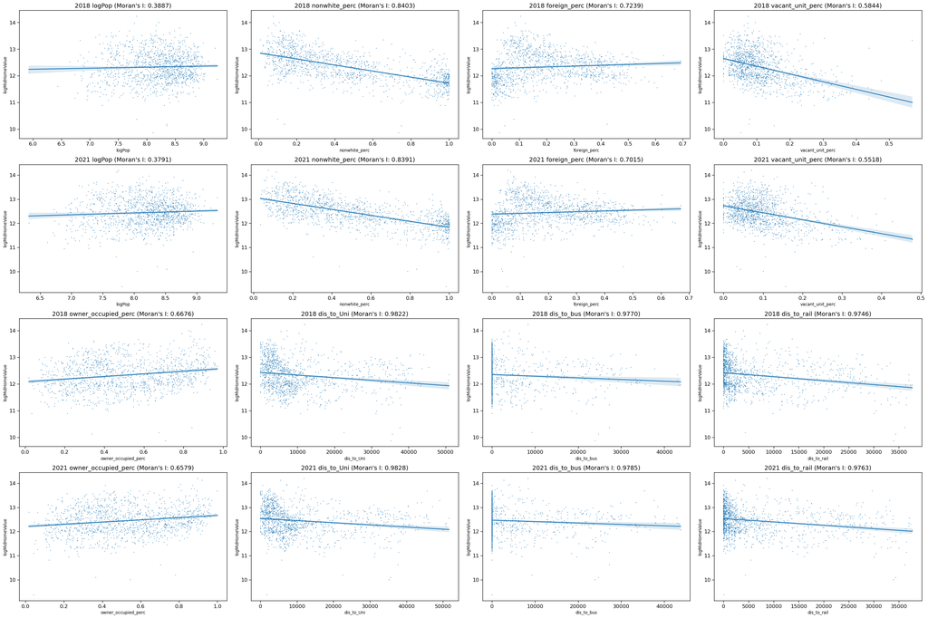

```python
from esda.moran import Moran
import libpysal

# Assuming acs_df_2018 and acs_df_2021 are your GeoDataFrames for the years 2018 and 2021

# List of columns to include in the Moran's plot matrix
columns = [
    'logPop', 'nonwhite_perc', 'foreign_perc', 'vacant_unit_perc',
    'owner_occupied_perc', 'dis_to_Uni', 'dis_to_bus', 'dis_to_rail'
]

# Function to create a spatial weights matrix
def create_weights(df):
    return libpysal.weights.Queen.from_dataframe(df)

# Function to calculate Moran's I for all columns
def calculate_all_morans_i(df, columns, w):
    return {column: Moran(df[column], w).I for column in columns}

# Create spatial weights matrices for both years
w_2018 = create_weights(acs_df_2018)
w_2021 = create_weights(acs_df_2021)

# Calculate Moran's I for all columns for both years
morans_i_2018 = calculate_all_morans_i(acs_df_2018, columns, w_2018)
morans_i_2021 = calculate_all_morans_i(acs_df_2021, columns, w_2021)

# Create the subplot grid with 4x4
fig, axs = plt.subplots(4, 4, figsize=(30, 20))  # Adjusted the size for better visibility

# Loop to plot each variable
for i, col in enumerate(columns):
    row = i // 4
    col_idx = i % 4
    sns.regplot(x=col, y='logMidHomeValue', data=acs_df_2018, ax=axs[row*2, col_idx], scatter_kws={'s': 0.5})
    axs[row*2, col_idx].set_title(f"2018 {col} (Moran's I: {morans_i_2018[col]:.4f})", fontsize=14)
    axs[row*2, col_idx].tick_params(axis='both', which='major', labelsize=12)

    sns.regplot(x=col, y='logMidHomeValue', data=acs_df_2021, ax=axs[row*2 + 1, col_idx], scatter_kws={'s': 0.5})
    axs[row*2 + 1, col_idx].set_title(f"2021 {col} (Moran's I: {morans_i_2021[col]:.4f})", fontsize=14)
    axs[row*2 + 1, col_idx].tick_params(axis='both', which='major', labelsize=12)

# Adjust layout and add a figure-wide title
plt.tight_layout()

plt.show()
```

## 6.4 OLS Regression

### 6.4.1 OLS for 2018

```python
variable_names = ['nonwhite_perc', 'foreign_perc', 'vacant_unit_perc', 'dis_to_rail']
```

```python
Varlist18= variable_names + ["ridership_2018"]
acs_df_2018[acs_df_2018[Varlist18].isnull().any(axis=1)]
```

|  | STATEFP | COUNTYFP | TRACTCE | GEOID | NAME_x | NAMELSAD | MTFCC | FUNCSTAT | ALAND | AWATER | ... | dis_to_Uni | closestUni | is_private | dis_to_bus | dis_to_rail | station_id | ridership_2018 | ridership_2021 | dis_to_CBD | is_CBD |
| --- | --- | --- | --- | --- | --- | --- | --- | --- | --- | --- | --- | --- | --- | --- | --- | --- | --- | --- | --- | --- | --- |
| 55 | 17 | 031 | 980100 | 17031980100 | 9801 | Census Tract 9801 | G5020 | S | 2981781 | 0 | ... | 13402.991508 | Loyola_Health_Sciences | 1 | 0.000000 | 0.000000 | 930.0 | 8599.833333 | 3180.250000 | 18247.821379 | 0 |
| 323 | 17 | 031 | 980000 | 17031980000 | 9800 | Census Tract 9800 | G5020 | S | 19890200 | 92402 | ... | 14399.445316 | Loyola_Health_Sciences | 1 | 3325.041188 | 0.000000 | 890.0 | 11400.916667 | 5028.833333 | 30080.554490 | 0 |
| 750 | 17 | 031 | 381700 | 17031381700 | 3817 | Census Tract 3817 | G5020 | S | 196802 | 0 | ... | 3311.314365 | Illinois Tech | 1 | 0.000000 | 292.471936 | 1230.0 | 2879.500000 | 1110.916667 | 11248.677147 | 0 |
| 1161 | 17 | 031 | 990000 | 17031990000 | 9900 | Census Tract 9900 | G5020 | S | 0 | 1717072182 | ... | 755.516274 | Loyola_Lake_Shore | 1 | 296.765334 | 1028.539570 | 1300.0 | 5129.833333 | 1953.583333 | 2233.874727 | 1 |

4 rows × 56 columns

```python
acs_df_2018 = acs_df_2018.dropna(subset=Varlist18+["logMidHomeValue"])
```

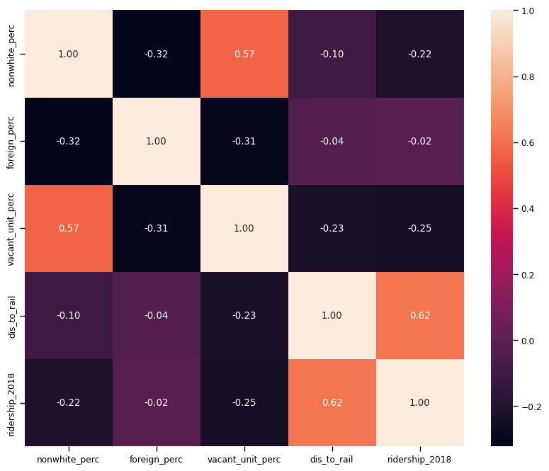

```python
correlation_matrix = acs_df_2018[Varlist18].corr()
plt.figure(figsize=(10, 8))
sns.heatmap(correlation_matrix, annot=True, fmt=".2f")
plt.show()
```

```python
from statsmodels.stats.outliers_influence import variance_inflation_factor
vif_data = pd.DataFrame()
vif_data["feature"] = acs_df_2018[Varlist18].columns
vif_data["VIF"] = [variance_inflation_factor(acs_df_2018[Varlist18].values, i) for i in range(len(acs_df_2018[Varlist18].columns))]
vif_data
```

|  | feature | VIF |
| --- | --- | --- |
| 0 | nonwhite_perc | 4.199090 |
| 1 | foreign_perc | 1.908475 |
| 2 | vacant_unit_perc | 4.076822 |
| 3 | dis_to_rail | 2.522510 |
| 4 | ridership_2018 | 4.002518 |

```python
OLS18 = spreg.OLS(
    acs_df_2018[["logMidHomeValue"]].values,
    acs_df_2018[Varlist18].values,
    name_y="logMidHomeValue",
    name_x=Varlist18,
)
print(OLS18.summary)
```

```
REGRESSION RESULTS
------------------

SUMMARY OF OUTPUT: ORDINARY LEAST SQUARES
-----------------------------------------
Data set            :     unknown
Weights matrix      :        None
Dependent Variable  :logMidHomeValue                Number of Observations:        1273
Mean dependent var  :     12.3303                Number of Variables   :           6
S.D. dependent var  :      0.5604                Degrees of Freedom    :        1267
R-squared           :      0.5475
Adjusted R-squared  :      0.5457
Sum squared residual:     180.722                F-statistic           :    306.6374
Sigma-square        :       0.143                Prob(F-statistic)     :  3.197e-215
S.E. of regression  :       0.378                Log likelihood        :    -563.753
Sigma-square ML     :       0.142                Akaike info criterion :    1139.505
S.E of regression ML:      0.3768                Schwarz criterion     :    1170.400

------------------------------------------------------------------------------------
            Variable     Coefficient       Std.Error     t-Statistic     Probability
------------------------------------------------------------------------------------
            CONSTANT        13.40960         0.03815       351.51406         0.00000
       nonwhite_perc        -1.16660         0.04251       -27.44573         0.00000
        foreign_perc        -0.78300         0.07915        -9.89314         0.00000
    vacant_unit_perc        -1.38949         0.17113        -8.11926         0.00000
         dis_to_rail        -0.00002         0.00000        -9.92575         0.00000
      ridership_2018        -0.00003         0.00000        -6.67313         0.00000
------------------------------------------------------------------------------------

REGRESSION DIAGNOSTICS
MULTICOLLINEARITY CONDITION NUMBER            8.662

TEST ON NORMALITY OF ERRORS
TEST                             DF        VALUE           PROB
Jarque-Bera                       2         225.992           0.0000

DIAGNOSTICS FOR HETEROSKEDASTICITY
RANDOM COEFFICIENTS
TEST                             DF        VALUE           PROB
Breusch-Pagan test                5         134.065           0.0000
Koenker-Bassett test              5          66.112           0.0000
================================ END OF REPORT =====================================
```

### 6.4.2 OLS Model for 2021

```python
Varlist21= variable_names + ["ridership_2021"]
acs_df_2021 = acs_df_2021.dropna(subset=Varlist21+["logMidHomeValue"])
acs_df_2021[acs_df_2021[Varlist21].isnull().any(axis=1)]
```

|  | STATEFP | COUNTYFP | TRACTCE | GEOID | NAME_x | NAMELSAD | MTFCC | FUNCSTAT | ALAND | AWATER | ... | dis_to_Uni | closestUni | is_private | dis_to_bus | dis_to_rail | station_id | ridership_2018 | ridership_2021 | dis_to_CBD | is_CBD |
| --- | --- | --- | --- | --- | --- | --- | --- | --- | --- | --- | --- | --- | --- | --- | --- | --- | --- | --- | --- | --- | --- |

0 rows × 56 columns

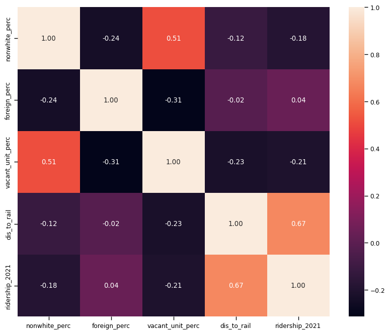

```python
correlation_matrix = acs_df_2021[Varlist21].corr()
plt.figure(figsize=(10, 8))
sns.heatmap(correlation_matrix, annot=True, fmt=".2f")
plt.show()
```

```python
vif_data["feature"] = acs_df_2021[Varlist21].columns
vif_data["VIF"] = [variance_inflation_factor(acs_df_2021[Varlist21].values, i) for i in range(len(acs_df_2021[Varlist21].columns))]
vif_data
```

|  | feature | VIF |
| --- | --- | --- |
| 0 | nonwhite_perc | 4.442830 |
| 1 | foreign_perc | 2.061458 |
| 2 | vacant_unit_perc | 3.761674 |
| 3 | dis_to_rail | 2.854869 |
| 4 | ridership_2021 | 4.462365 |

```python
OLS21 = spreg.OLS(
    acs_df_2021[["logMidHomeValue"]].values,
    acs_df_2021[Varlist21].values,
    name_y="logMidHomeValue",
    name_x=Varlist21,
)
print(OLS21.summary)
```

```
REGRESSION RESULTS
------------------

SUMMARY OF OUTPUT: ORDINARY LEAST SQUARES
-----------------------------------------
Data set            :     unknown
Weights matrix      :        None
Dependent Variable  :logMidHomeValue                Number of Observations:        1312
Mean dependent var  :     12.4445                Number of Variables   :           6
S.D. dependent var  :      0.5577                Degrees of Freedom    :        1306
R-squared           :      0.5546
Adjusted R-squared  :      0.5529
Sum squared residual:     181.573                F-statistic           :    325.2886
Sigma-square        :       0.139                Prob(F-statistic)     :  2.122e-226
S.E. of regression  :       0.373                Log likelihood        :    -564.309
Sigma-square ML     :       0.138                Akaike info criterion :    1140.619
S.E of regression ML:      0.3720                Schwarz criterion     :    1171.695

------------------------------------------------------------------------------------
            Variable     Coefficient       Std.Error     t-Statistic     Probability
------------------------------------------------------------------------------------
            CONSTANT        13.51249         0.03564       379.17654         0.00000
       nonwhite_perc        -1.25649         0.04149       -30.28275         0.00000
        foreign_perc        -0.47560         0.07738        -6.14611         0.00000
    vacant_unit_perc        -1.19184         0.17808        -6.69273         0.00000
         dis_to_rail        -0.00001         0.00000        -8.75023         0.00000
      ridership_2021        -0.00006         0.00001        -6.96717         0.00000
------------------------------------------------------------------------------------

REGRESSION DIAGNOSTICS
MULTICOLLINEARITY CONDITION NUMBER            8.319

TEST ON NORMALITY OF ERRORS
TEST                             DF        VALUE           PROB
Jarque-Bera                       2         671.549           0.0000

DIAGNOSTICS FOR HETEROSKEDASTICITY
RANDOM COEFFICIENTS
TEST                             DF        VALUE           PROB
Breusch-Pagan test                5          68.764           0.0000
Koenker-Bassett test              5          25.558           0.0001
================================ END OF REPORT =====================================
```

### 6.4.3 Interpretation of OLS Models

According to the OLS model in 2018, the negative coefficients for demographic factors (nonwhite_perc, foreign_perc) and vacancy rates may suggest socio-economic factors or preferences affecting housing values in areas with higher proportions of these demographics or more vacant homes. The slight influence of distance to rail stations on lowering home values could indicate a preference for proximity to transit options, which typically enhances property values. However, the negative effect of ridership may need further exploration to understand underlying causes, such as whether higher ridership is associated with negative externalities that affect housing prices. This may indicates that the affluent group does not tend to use public transit.

In 2021, all predictors are highly significant with p-values of 0.00000, similar to the 2018 model, suggesting strong evidence against the null hypothesis for all included variables. In the 2021 model, notably, the impact of the non-white percentage has become more negative, and the coefficient for ridership is more negative compared to the previous year. This suggests that an increase in ridership now has a stronger negative correlation with housing values than it did before. This shows that in the post- Covid 19 era, the difference in transportation usage between ethnic minorities and white people is increasing, and the use of public transportation and subway distances from properties is more associated with lower housing affordability.

## 6.5 Spatial Regime Model

### 6.5.1 Spatial Regime Model for 2018

```python
SR18 = spreg.OLS_Regimes(
    acs_df_2018[["logMidHomeValue"]].values,
    acs_df_2018[Varlist18].values,
    acs_df_2018["is_CBD"].tolist(),
    constant_regi="many",
    regime_err_sep=False,
    name_y="logMidHomeValue",
    name_x=Varlist18,
)
```

```python
res = pd.DataFrame(
    {
        # Pull out regression coefficients and
        # flatten as they are returned as Nx1 array
        "Coeff.": SR18.betas.flatten(),
        # Pull out and flatten standard errors
        "Std. Error": SR18.std_err.flatten(),
        # Pull out P-values from t-stat object
        "P-Value": [i[1] for i in SR18.t_stat],
    },
    index=SR18.name_x,
)
## Extract variables for the coastal regime
CBD = [i for i in res.index if "1_" in i]
CBD = res.loc[CBD, :].rename(lambda i: i.replace("1_", ""))
## Build multi-index column names
CBD.columns = pd.MultiIndex.from_product(
    [["CBD"], CBD.columns]
)
# Non-CBD
## Extract variables for the non-coastal regime
out = [i for i in res.index if "0_" in i]
out = res.loc[out, :].rename(lambda i: i.replace("0_", ""))
## Build multi-index column names
out.columns = pd.MultiIndex.from_product(
    [["Outside"], out.columns]
)
# Concat both models
pd.concat([CBD, out], axis=1)
```

|  | CBD Coeff. | CBD Std. Error | CBD P-Value | Outside Coeff. | Outside Std. Error | Outside P-Value |
| --- | --- | --- | --- | --- | --- | --- |
| CONSTANT | 12.972485 | 0.269899 | 2.508697e-287 | 13.455864 | 0.037573 | 0.000000e+00 |
| nonwhite_perc | 0.028624 | 0.843532 | 9.729353e-01 | -1.100378 | 0.041823 | 5.689917e-122 |
| foreign_perc | -1.023915 | 1.081883 | 3.441164e-01 | -0.812831 | 0.076990 | 5.009319e-25 |
| vacant_unit_perc | 0.618738 | 0.838265 | 4.605805e-01 | -1.851549 | 0.173497 | 1.627757e-25 |
| dis_to_rail | 0.000271 | 0.000317 | 3.934378e-01 | -0.000013 | 0.000002 | 6.172307e-16 |
| ridership_2018 | 0.000012 | 0.000023 | 6.145541e-01 | -0.000035 | 0.000004 | 3.158383e-19 |

### 6.5.2 Spatial Regime Model for 2021

```python
SR21 = spreg.OLS_Regimes(
    acs_df_2021[["logMidHomeValue"]].values,
    acs_df_2021[Varlist21].values,
    acs_df_2021["is_CBD"].tolist(),
    constant_regi="many",
    regime_err_sep=False,
    name_y="logMidHomeValue",
    name_x=Varlist21,
)
```

```python
res = pd.DataFrame(
    {
        # Pull out regression coefficients and
        # flatten as they are returned as Nx1 array
        "Coeff.": SR21.betas.flatten(),
        # Pull out and flatten standard errors
        "Std. Error": SR21.std_err.flatten(),
        # Pull out P-values from t-stat object
        "P-Value": [i[1] for i in SR21.t_stat],
    },
    index=SR21.name_x,
)
## Extract variables for the coastal regime
CBD = [i for i in res.index if "1_" in i]
CBD = res.loc[CBD, :].rename(lambda i: i.replace("1_", ""))
## Build multi-index column names
CBD.columns = pd.MultiIndex.from_product(
    [["CBD"], CBD.columns]
)
# Non-CBD
## Extract variables for the non-coastal regime
out = [i for i in res.index if "0_" in i]
out = res.loc[out, :].rename(lambda i: i.replace("0_", ""))
## Build multi-index column names
out.columns = pd.MultiIndex.from_product(
    [["Outside"], out.columns]
)
# Concat both models
pd.concat([CBD, out], axis=1)
```

|  | CBD Coeff. | CBD Std. Error | CBD P-Value | Outside Coeff. | Outside Std. Error | Outside P-Value |
| --- | --- | --- | --- | --- | --- | --- |
| CONSTANT | 13.266159 | 0.303604 | 2.258006e-257 | 13.528267 | 0.035486 | 0.000000e+00 |
| nonwhite_perc | -0.906958 | 0.787932 | 2.499188e-01 | -1.201198 | 0.041690 | 1.383110e-141 |
| foreign_perc | 0.110858 | 0.759801 | 8.840197e-01 | -0.511979 | 0.076788 | 3.837076e-11 |
| vacant_unit_perc | 0.715346 | 0.988215 | 4.692716e-01 | -1.525842 | 0.182153 | 1.393752e-16 |
| dis_to_rail | 0.000205 | 0.000305 | 5.016357e-01 | -0.000012 | 0.000002 | 1.243038e-13 |
| ridership_2021 | -0.000029 | 0.000064 | 6.472906e-01 | -0.000078 | 0.000009 | 2.536415e-16 |

## 6.6 Spatial Lag Model

### 6.6.1 Spatial Lag Model for 2018

```python
knn18 = weights.KNN.from_dataframe(acs_df_2018, k=20)
SLM18 = spreg.GM_Lag(
    acs_df_2018[["logMidHomeValue"]].values,
    acs_df_2018[Varlist18].values,
    w=knn18,
    name_y="logMidHomeValue",
    name_x=Varlist18,
)
print(SLM18.summary)
```

```
REGRESSION RESULTS
------------------

SUMMARY OF OUTPUT: SPATIAL TWO STAGE LEAST SQUARES
--------------------------------------------------
Data set            :     unknown
Weights matrix      :     unknown
Dependent Variable  :logMidHomeValue                Number of Observations:        1273
Mean dependent var  :     12.3303                Number of Variables   :           7
S.D. dependent var  :      0.5604                Degrees of Freedom    :        1266
Pseudo R-squared    :      0.7732
Spatial Pseudo R-squared:  0.6118

------------------------------------------------------------------------------------
            Variable     Coefficient       Std.Error     z-Statistic     Probability
------------------------------------------------------------------------------------
            CONSTANT         4.31300         0.51284         8.41001         0.00000
       nonwhite_perc        -0.49124         0.04854       -10.12075         0.00000
        foreign_perc        -0.61779         0.05694       -10.84917         0.00000
    vacant_unit_perc        -0.81194         0.12575        -6.45677         0.00000
         dis_to_rail        -0.00000         0.00000        -3.70018         0.00022
      ridership_2018        -0.00001         0.00000        -4.50443         0.00001
   W_logMidHomeValue         0.03468         0.00195        17.76240         0.00000
------------------------------------------------------------------------------------
Instrumented: W_logMidHomeValue
Instruments: W_dis_to_rail, W_foreign_perc, W_nonwhite_perc,
             W_ridership_2018, W_vacant_unit_perc
================================ END OF REPORT =====================================
```

### 6.6.2 Spatial Lag Model for 2021

```python
knn21 = weights.KNN.from_dataframe(acs_df_2021, k=20)
SLM21 = spreg.GM_Lag(
    acs_df_2021[["logMidHomeValue"]].values,
    acs_df_2021[Varlist21].values,
    w=knn21,
    name_y="logMidHomeValue",
    name_x=Varlist21,
)
print(SLM21.summary)
```

```
REGRESSION RESULTS
------------------

SUMMARY OF OUTPUT: SPATIAL TWO STAGE LEAST SQUARES
--------------------------------------------------
Data set            :     unknown
Weights matrix      :     unknown
Dependent Variable  :logMidHomeValue                Number of Observations:        1312
Mean dependent var  :     12.4445                Number of Variables   :           7
S.D. dependent var  :      0.5577                Degrees of Freedom    :        1305
Pseudo R-squared    :      0.7552
Spatial Pseudo R-squared:  0.6030

------------------------------------------------------------------------------------
            Variable     Coefficient       Std.Error     z-Statistic     Probability
------------------------------------------------------------------------------------
            CONSTANT         4.45694         0.56793         7.84765         0.00000
       nonwhite_perc        -0.52914         0.05501        -9.61847         0.00000
        foreign_perc        -0.48426         0.05749        -8.42402         0.00000
    vacant_unit_perc        -0.76462         0.13497        -5.66532         0.00000
         dis_to_rail        -0.00000         0.00000        -3.05028         0.00229
      ridership_2021        -0.00003         0.00001        -4.08048         0.00004
   W_logMidHomeValue         0.03421         0.00214        15.96210         0.00000
------------------------------------------------------------------------------------
Instrumented: W_logMidHomeValue
Instruments: W_dis_to_rail, W_foreign_perc, W_nonwhite_perc,
             W_ridership_2021, W_vacant_unit_perc
================================ END OF REPORT =====================================
```

## 6.6 Spatial Durbin Model

### 6.6.1 Spatial Durbin Model for 2018

```python
knn18.transform = "R"
lag_variables_used = acs_df_2018.filter(['nonwhite_perc', 'foreign_perc', 'vacant_unit_perc', 'dis_to_rail', 'ridership_2018'])
wx = lag_variables_used.apply(lambda y: weights.spatial_lag.lag_spatial(knn18, y))
wx = wx.rename(columns=lambda c: "w_"+ c)
slx_exog18 = acs_df_2018[Varlist18].join(wx)
```

```python
knn21.transform = "R"
lag_variables_used = acs_df_2021.filter(['nonwhite_perc', 'foreign_perc', 'vacant_unit_perc', 'dis_to_rail', 'ridership_2021'])
wx = lag_variables_used.apply(lambda y: weights.spatial_lag.lag_spatial(knn21, y))
wx = wx.rename(columns=lambda c: "w_"+ c)
slx_exog21 = acs_df_2021[Varlist21].join(wx)
```

```python
SDM18 = spreg.GM_Lag(
    acs_df_2018[["logMidHomeValue"]].values,
    slx_exog18.values,
    w=knn18,
    name_y="logMidHomeValue",
    name_x=slx_exog18.columns.tolist(),
)
print(SDM18.summary)
```

```
REGRESSION RESULTS
------------------

SUMMARY OF OUTPUT: SPATIAL TWO STAGE LEAST SQUARES
--------------------------------------------------
Data set            :     unknown
Weights matrix      :     unknown
Dependent Variable  :logMidHomeValue                Number of Observations:        1273
Mean dependent var  :     12.3303                Number of Variables   :          12
S.D. dependent var  :      0.5604                Degrees of Freedom    :        1261
Pseudo R-squared    :      0.0202
Spatial Pseudo R-squared: omitted due to rho outside the boundary (-1, 1).

------------------------------------------------------------------------------------
            Variable     Coefficient       Std.Error     z-Statistic     Probability
------------------------------------------------------------------------------------
            CONSTANT       -34.42374
       nonwhite_perc        -2.78033         5.08284        -0.54700         0.58438
        foreign_perc         2.70351         8.60099         0.31433         0.75327
    vacant_unit_perc        -2.36103        13.75619        -0.17163         0.86373
         dis_to_rail         0.00001         0.00063         0.01937         0.98454
      ridership_2018         0.00008         0.00052         0.14965         0.88104
     w_nonwhite_perc         6.50409
      w_foreign_perc         1.11162        14.24899         0.07801         0.93782
  w_vacant_unit_perc         7.89387
       w_dis_to_rail        -0.00002         0.00007        -0.23264         0.81604
    w_ridership_2018         0.00001         0.00020         0.03967         0.96835
   W_logMidHomeValue         1.45985
------------------------------------------------------------------------------------
Instrumented: W_logMidHomeValue
Instruments: W_dis_to_rail, W_foreign_perc, W_nonwhite_perc,
             W_ridership_2018, W_vacant_unit_perc, W_w_dis_to_rail,
             W_w_foreign_perc, W_w_nonwhite_perc, W_w_ridership_2018,
             W_w_vacant_unit_perc
Warning: *** WARNING: Estimate for spatial lag coefficient is outside the boundary (-1, 1). ***
================================ END OF REPORT =====================================
```

### 6.6.2 Limitation for Spatial Durbin Model

When comparing the Spatial Durbin Model (SDM) and Spatial Lag Model (SLM), SDM shows significantly lower pseudo R-squared values than SLM, indicating weaker explanatory variable variability. In addition, the estimated value of the spatial lag coefficient of SDM exceeds the theoretical boundary, indicating that the model may not be suitable for the data structure. Therefore, it has been decided not to continue using SDM and instead adopt the better performing SLM.

# 7 Limitations

Overall, while the results of the study can explain the research questions, they did not meet the initial expectations. We started off with a very large number of ideas when exploring the dataset, which can be found in the pre-processing of the data, where we calculated the ridership of each bus route on weekdays, Saturdays, and Sundays, and we also planned to use whether or not the subway stations are equipped with ADA accessibility features and parking lots as dummy variables, and we also planned to explore whether or not the overnight subway is also a factor that affects the price of the house (the red line and the blue line ). We have listed the various characteristics of transportation that may affect house prices and processed the data accordingly in our preliminary exploration, and have devoted a lot of time to this.

As the research progressed, a variety of problems arrived, starting with the fact that many of the calculated variables did not work well. For example, the passenger volume of bus routes could not be accurately assigned to individual stops, and could not be combined with the census tract for spatial analysis. We also computed a number of distance variables for universities to examine whether transportation around universities has a greater impact on housing prices, since we assume that college students in the city of Chicago commute predominantly by public transportation. However, at the end of the regression analysis, the entire calculation was abandoned because the VIFs of the variables were too large.

Problems within the dataset were also reflected in the regression analysis. Mathematical problems, such as that most tracts contained bus stops or are adjacent to them, resulted in more than half of the tracts having a 0 distance to a bus stop, so none of the regression models were successful in calculating the weights for that variable. Similarly, there are cases where log values are negative, weight matrices are singular, and so on. Unlike syntax errors, these are only possible causes of the error that can be found on the web, with no specific solution, so sorting out the data also becomes one of the factors limiting the depth of the research beyond the availability of the data.

# 8 Conclusion

This research explores the intricate relationship between housing prices, public transportation accessibility, and urban development in Chicago during 2018 and 2021. It delves into how proximity to transit options—such as subways and buses—and the demographic shifts within Chicago influence the housing market. The analysis, underpinned by spatial models and Ordinary Least Squares (OLS) regression, reveals significant spatial autocorrelation and the varying impacts of demographic and economic factors on housing values across different urban areas.

Additionally, the study observes a paradox where housing prices are higher near transit facilities, yet there is a negative correlation between ridership and housing prices, suggesting a mismatch of transportation resources. This indicates that while transit accessibility increases property values, the benefits of this accessibility may not be equitably distributed among all residents, particularly those who rely more heavily on public transit. This misalignment calls for urban planning that increases equity, ensuring that enhancements in transit infrastructure benefit all segments of the urban population.

These insights are critical for policymakers and urban planners aiming to foster equitable urban growth and enhance the livability of urban spaces while ensuring efficient access to essential services and maintaining housing affordability. The research underscores the need for nuanced urban planning strategies that consider the diverse needs of urban populations and the dynamic nature of urban transit systems.

# 9 Reference

Brueckner, J. K., & Rosenthal, S. S. (2009). Gentrification and neighborhood housing cycles: will America's future downtowns be rich?. The Review of Economics and Statistics, 91(4), 725-743.

Crum, G. (2020). Impact of Public Transit Access on Chicago Housing Prices.

Herath, S., & Maier, G. (2010). The hedonic price method in real estate and housing market research: a review of the literature.

Hess, D. B., & Almeida, T. M. (2007). Impact of proximity to light rail rapid transit on station-area property values in Buffalo, New York. Urban Studies, 44(5-6), 1041-1068.

Lee, S., & Smart, M. (2020). Public Transportation Accessibility, Proximity to New York City, and Residential Property Values in New Jersey. Hatfield Graduate Journal of Public Affairs, 4(1), 6.

Liu, D., Kwan, M. P., Kan, Z., & Song, Y. (2021). An integrated analysis of housing and transit affordability in the Chicago metropolitan area. The Geographical Journal, 187(2), 110-126.

Giuliano, G. (2005). Low income, public transit, and mobility. Transportation Research Record, 1927(1), 63-70.

Pamidimukkala, R. (2016). Impact of Rapid Transit on the Residential Market in Hudson County, New Jersey.

Regional Transportation Authority. (2021, April 19). Survey shows current riders are more likely to be essential workers or minorities, feel transit is safe. Retrieved from https://www.rtachicago.org/blog/2021/04/19/survey-shows-current-riders-are-more-likely-to-be-essential-workers-or-minorities-feel-transit-is-safe#:~:text=Survey%20results%20show%20that%20among,and%2012%20percent%20are%20Latino.

TransitCenter. (2021). TransitCenter Equity Dashboard: The Chicago Story. Retrieved from https://dashboard.transitcenter.org/story/chicago

U.S. Census Bureau. (2018). Commuting Characteristics by Sex: 5-year estimates, American Community Survey. Retrieved from https://data.ce nsus.gov/cedsci/table?t=Commuting&g=0100000US&y=2018&tid=ACSST5Y2018.S0801&hidePreview=false